# COD_20230301_HOST_1_QC_analysis

Minsik Kim

2023-03-14

## Loading packages

```r
#===============================================================================
#BTC.LineZero.Header.1.1.0
#===============================================================================
#R Markdown environment setup and reporting utility.
#===============================================================================
#RLB.Dependencies:
#   knitr, magrittr, pacman, rio, rmarkdown, rmdformats, tibble, yaml
#===============================================================================
#Input for document parameters, libraries, file paths, and options.
#=+=+=+=+=+=+=+=+=+=+=+=+=+=+=+=+=+=+=+=+=+=+=+=+=+=+=+=+=+=+=+=+=+=+=+=+=+=+=+=
knitr::opts_chunk$set(message=FALSE, warning = FALSE)

path_working <- "/Users/minsikkim/Dropbox (Partners HealthCare)/Project_SICAS2_microbiome/5_Scripts/MGK/Host_depletion_git/"
path_library <- "/Library/Frameworks/R.framework/Resources/library"
str_libraries <- c(
    "readxl", "phyloseq", "tidyverse", "pacman", "yaml"
)

path_working <- "/Users/minsikkim/Dropbox (Partners HealthCare)/Project_SICAS2_microbiome/5_Scripts/MGK/Host_depletion_git"
path_library <- "/Library/Frameworks/R.framework/Resources/library"
str_libraries <- c("readxl", "phyloseq", "tidyverse", "pacman", "yaml", "ggplot2", "vegan", "microbiome", "ggpubr", "viridis", "decontam", "gridExtra", "ggpubr", "lme4", "lmerTest", "writexl", "harrietr", "Maaslin2", "ggtext", "ggpmisc", "gridExtra", "gamm4", "reshape2", "kableExtra", "knitr")

YAML_header <-
'---
title: "Host-DNA depletion 1: data wrangling"
author: "Minsik Kim"
date: "2032.03.10"
output:
    rmdformats::downcute:
        downcute_theme: "chaos"
        code_folding: hide
        fig_width: 6
        fig_height: 6
---'
seed <- "20230314"

#=-=-=-=-=-=-=-=-=-=-=-=-=-=-=-=-=-=-=-=-=-=-=-=-=-=-=-=-=-=-=-=-=-=-=-=-=-=-=-=
#Loads libraries, file paths, and other document options.
#=-=-=-=-=-=-=-=-=-=-=-=-=-=-=-=-=-=-=-=-=-=-=-=-=-=-=-=-=-=-=-=-=-=-=-=-=-=-=-=
FUN.LineZero.Boot <- function() {
    .libPaths(path_library)

    require(pacman)
    pacman::p_load(c("knitr", "rmarkdown", "rmdformats", "yaml"))

    knitr::opts_knit$set(root.dir = path_working)

    str_libraries |> unique() |> sort() -> str_libraries
    pacman::p_load(char = str_libraries)

    set.seed(seed)
}
FUN.LineZero.Boot()
```

```
##
##  /var/folders/z2/kwm76s1n3jj2sjznjyj9thqc0000gn/T//Rtmp7e3TsQ/downloaded_packages
```

```r
#=-=-=-=-=-=-=-=-=-=-=-=-=-=-=-=-=-=-=-=-=-=-=-=-=-=-=-=-=-=-=-=-=-=-=-=-=-=-=-=
#Outputs R environment report.
#=-=-=-=-=-=-=-=-=-=-=-=-=-=-=-=-=-=-=-=-=-=-=-=-=-=-=-=-=-=-=-=-=-=-=-=-=-=-=-=
FUN.LineZero.Report <- function() {
    cat("Line Zero Environment:\n\n")
    paste("R:", pacman::p_version(), "\n") |> cat()
    cat("Libraries:\n")
    for (str_libraries in str_libraries) {
        paste(
            "    ", str_libraries, ": ", pacman::p_version(package = str_libraries),
            "\n", sep = ""
        ) |> cat()
    }
    paste("\nOperating System:", pacman::p_detectOS(), "\n") |> cat()
    paste("    Library Path:", path_library, "\n") |> cat()
    paste("    Working Path:", path_working, "\n") |> cat()
    paste("Seed:", seed, "\n\n") |> cat()
    cat("YAML Header:\n")
    cat(YAML_header)
}
FUN.LineZero.Report()
```

```
## Line Zero Environment:
##
## R: 4.2.2
## Libraries:
##     readxl: 1.4.2
##     phyloseq: 1.42.0
##     tidyverse: 2.0.0
##     pacman: 0.5.1
##     yaml: 2.3.7
##     ggplot2: 3.4.1
##     vegan: 2.6.4
##     microbiome: 1.20.0
##     ggpubr: 0.6.0
##     viridis: 0.6.2
##     decontam: 1.18.0
##     gridExtra: 2.3
##     ggpubr: 0.6.0
##     lme4: 1.1.31
##     lmerTest: 3.1.3
##     writexl: 1.4.2
##     harrietr: 0.2.3
##     Maaslin2: 1.12.0
##     ggtext: 0.1.2
##     ggpmisc: 0.5.2
##     gridExtra: 2.3
##     gamm4: 0.2.6
##     reshape2: 1.4.4
##     kableExtra: 1.3.4
##     knitr: 1.42
##
## Operating System: Darwin
##     Library Path: /Library/Frameworks/R.framework/Resources/library
##     Working Path: /Users/minsikkim/Dropbox (Partners HealthCare)/Project_SICAS2_microbiome/5_Scripts/MGK/Host_depletion_git
## Seed: 20230314
##
## YAML Header:
## ---
## title: "Host-DNA depletion 1: data wrangling"
## author: "Minsik Kim"
## date: "2032.03.10"
## output:
##     rmdformats::downcute:
##         downcute_theme: "chaos"
##         code_folding: hide
##         fig_width: 6
##         fig_height: 6
## ---
```

#Script description#

*1. Loading data 1.1. phyloseq obejct 1.2. qPCR data (controls)

2. QC Q1. How many samples failed sequencing Q2. How were changes in read stats and host DNA proportion? Q3. How were the extraction controls Q4. Prevalence / abundance filtering - red flag
3. Exploratory analysis *

*data input required:*

*Meta data*

- qPCR - bacteria
- qPCR - human
- qPCR host %
- Raw reads
- final reads
- sequencing host %
- library prep failure status
- Raw reads
- subject_id
- treatment
- sample_type
- subject_id

*Sequencing result*

- samples
- controls

*Analysis*

0. calculation of alpha-diversity indices
1. qPCR, by smaple type and treatment A. Total DNA B. Host DNA C. Bacterial DNA D. Host %
2. Sequencing results (treatment, raw reads, host reads, % host, final reads) –> both stratified and nonstratified library prep % vs sample_type + treatment + sample_type * treatment + subject_id (binary) log10(Final reads) vs sample_type + treatment + sample_type * treatment + subject_id (linear or binary, see regular and cumulative distribution) Host DNA % vs sample_type + treatment + sample_type * treatment + subject_id (linear or binary, see regular and cumulative distribution) –> both stratified and nonstratified
3. LM of taxa alpha diversity (richness) –> both stratified and nonstratified
4. Permanova (Taxa dist ~ log10(final reads) + sample_type + treatment + sample_type * treatment + subject_id) –> both stratified and nonstratified
5. DA analysis for taxa, by sample type and treatment –> both stratified and nonstratified –> look at level groups as well - phylum, etc.
6. Decontam - stratified by treatment –> both stratified and nonstratified
7. LM of taxa alpha diversity (Shannon) –> both stratified and nonstratified
8. LM of taxa alpha diversity (InvSimpson) –> both stratified and nonstratified
9. LM of taxa alpha diversity (BPI) –> both stratified and nonstratified
10. LM of function alpha diversity (richness) –> both stratified and nonstratified
11. LM of function alpha diversity (Shannon) –> both stratified and nonstratified
12. LM of function alpha diversity (InvSimpson) –> both stratified and nonstratified
13. LM of function alpha diversity (BPI) –> both stratified and nonstratified
14. permanova of function alpha diversity –> both stratified and nonstratified

#Loading data#

```r
# Loading files -----------------------------------------------------------
#loading tidy phyloseq object
phyloseq <- read_rds("/Users/minsikkim/Dropbox (Partners HealthCare)/Project_SICAS2_microbiome/4_Data/2_Tidy/Phyloseq/PHY_20221129_MGK_host_tidy_tax.rds")

        ####Need to be removed after adding sequenicing data
                data_qPCR <- read_csv("/Users/minsikkim/Dropbox (Partners HealthCare)/Project_SICAS2_microbiome/7_Manuscripts/2022_MGK_Host_Depletion/Tables/DAT_20230122_MGK_host_control_qPCR.csv")
                #qPCR data of all the samples sent out sequencing
                data_qPCR <- subset(data_qPCR, data_qPCR$baylor_other_id %in% c(sample_names(phyloseq$phyloseq_count)) | data_qPCR$baylor_other_id %in% c(read_excel("/Users/minsikkim/Dropbox (Partners HealthCare)/Project_Baylor/3_Documentation/Communications/2023-01-24_baylor_shipping_sicas2_nasal_host_depleted/CMMR_MetadataCapture_20230124_LaiP-PQ00430_SICAS2_NS.xlsx", skip = 27) %>% data.frame %>% .$`Optional..............secondary.ID`))

                data_qPCR <- subset(data_qPCR, data_qPCR$sample_type %in% c("BAL", "nasal_swab", "Sputum", "neg_depletion", "pos_depletion"))
                data_qPCR$sample_type <- factor(data_qPCR$sample_type, levels = c("BAL", "nasal_swab", "Sputum", "pos_depletion", "neg_depletion"),
                                                labels = c("BAL", "Nasal swab", "Sputum", "P depletion", "N depletion"))
                data_qPCR$treatment <- factor(data_qPCR$treatment, levels = c("control", "lyPMA", "benzonase", "host_zero", "molysis", "qiaamp"),
                                                labels = c("Control", "lyPMA", "Benzonase", "Host zero", "Molysis", "QIAamp"))

#sample data loading
sample_data <- sample_data(phyloseq$phyloseq_count)
```

2. QC Q1. How many samples failed sequencing Q2. How were changes in read stats and host DNA proportion? Q3. How were the extraction controls Q4. Decontam - were there any contaminants?

# Q1. How many samples failed in sequencing?

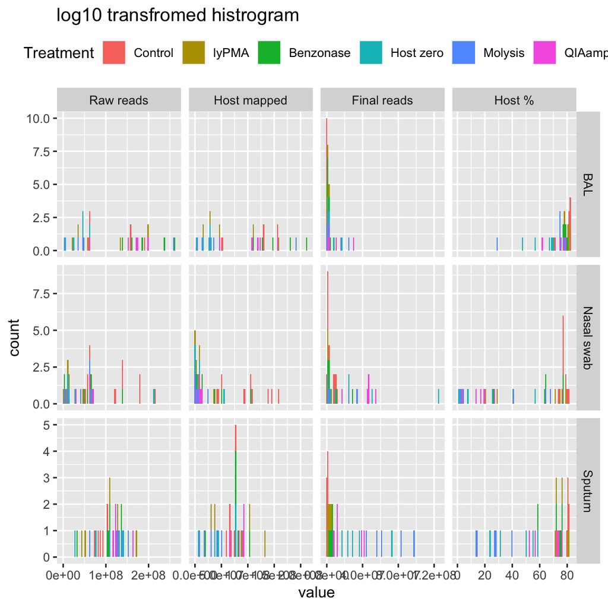

```r
# Initail QC --------------------------------------------------------------
        #Quesetions - QC

#Q0. How many samples failed in sequencing

## figures -----raw data

sample_data %>%
        subset(., !is.na(.$subject_id)) %>%
        data.frame() %>%
        mutate(host_seq_percent = sequencing_host_prop * 100,
               .after = sequencing_host_prop,) %>%
        gather(feature, value, Raw_reads:host_seq_percent) %>%
        group_by(feature, sample_type) %>%
        subset(., .$feature %in% c("Raw_reads", "Host_mapped", "Final_reads", "host_seq_percent")) %>%
        mutate(feature = factor(feature, levels = c("Raw_reads", "Host_mapped", "Final_reads", "host_seq_percent"), labels = c("Raw reads", "Host mapped", "Final reads", "Host %"))) %>%
        ggplot(aes(x = value, fill = treatment)) +
                geom_histogram(bins = 97) +
                theme(legend.position = "top") +
                guides(fill=guide_legend(title="Treatment", nrow = 1)) +
                facet_grid(sample_type~feature, scales = "free") +
                ggtitle("log10 transfromed histrogram")
```

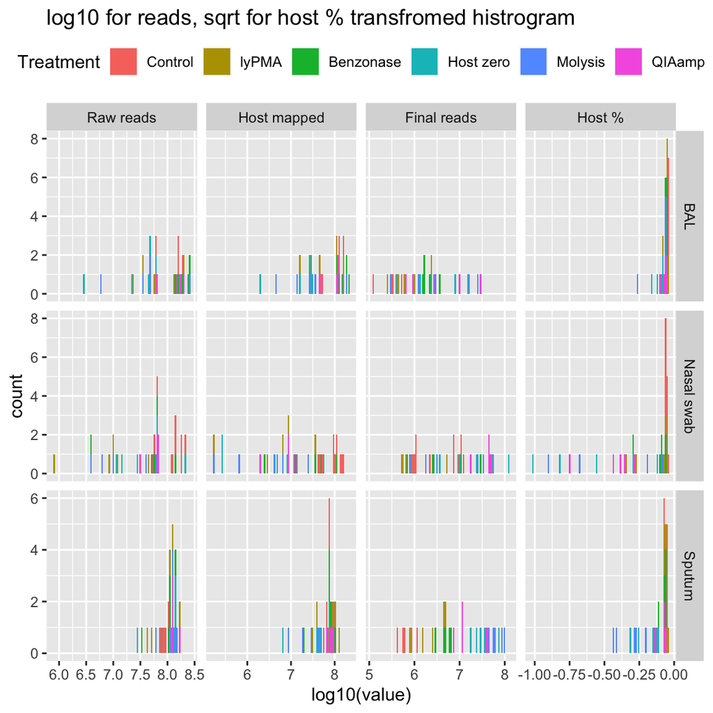

```r
## figures -----log10

sample_data %>%
        subset(., !is.na(.$subject_id)) %>%
        data.frame() %>%
        mutate(host_seq_percent = sqrt(sequencing_host_prop),
               .after = sequencing_host_prop,) %>%
        gather(feature, value, Raw_reads:host_seq_percent) %>%
        group_by(feature, sample_type) %>%
        subset(., .$feature %in% c("Raw_reads", "Host_mapped", "Final_reads", "host_seq_percent")) %>%
        mutate(feature = factor(feature, levels = c("Raw_reads", "Host_mapped", "Final_reads", "host_seq_percent"), labels = c("Raw reads", "Host mapped", "Final reads", "Host %"))) %>%
        ggplot(aes(x = log10(value), fill = treatment)) +
                geom_histogram(bins = 97) +
                theme(legend.position = "top") +
                guides(fill=guide_legend(title="Treatment", nrow = 1)) +
                facet_grid(sample_type~feature, scales = "free") +
                ggtitle("log10 for reads, sqrt for host % transfromed histrogram")
```

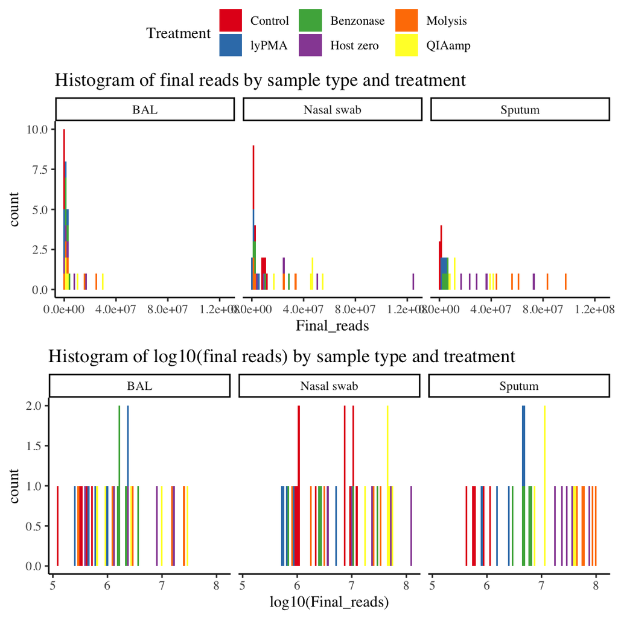

```r
# no somaple showed 0 reads

ggarrange(ggplot(sample_data %>% subset(., !is.na(.$subject_id)) %>% data.frame(), aes(x = Final_reads, fill = treatment)) +
                geom_histogram(bins = 97) +
                facet_wrap(~sample_type) +
                theme_classic(base_family = "serif") +
                ggtitle("Histogram of final reads by sample type and treatment") +
                scale_fill_manual(values = c("#e41a1c", "#377eb8", "#4daf4a", "#984ea3", "#ff7f00", "#ffff33"), name = "Treatment"),
             ggplot(sample_data %>% subset(., !is.na(.$subject_id)) %>% data.frame(), aes(x = log10(Final_reads), fill = treatment)) +
                geom_histogram(bins = 97) +
                facet_wrap(~sample_type) +
                theme_classic(base_family = "serif") +
                ggtitle("Histogram of log10(final reads) by sample type and treatment") +
                scale_fill_manual(values = c("#e41a1c", "#377eb8", "#4daf4a", "#984ea3", "#ff7f00", "#ffff33"), name = "Treatment"),
          common.legend = T, ncol = 1)
```

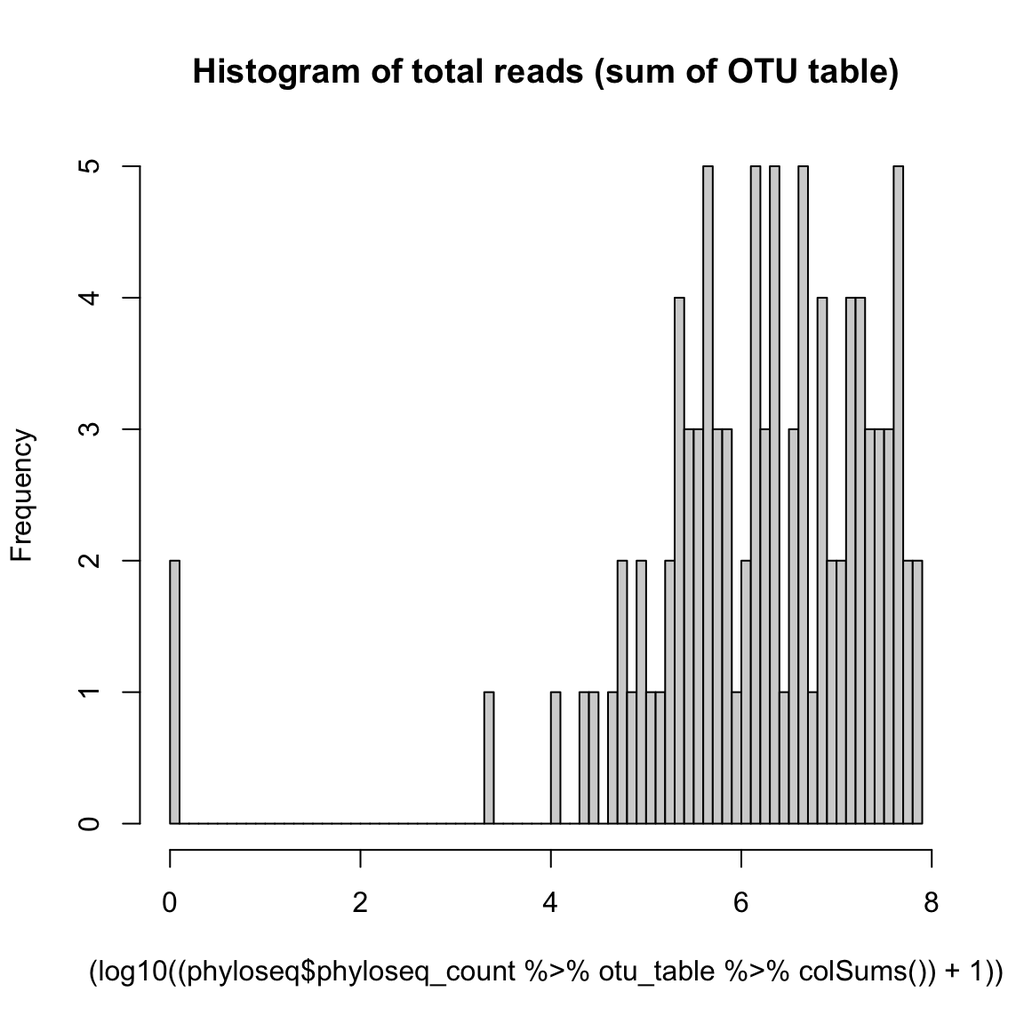

```r
hist((log10((phyloseq$phyloseq_count %>% otu_table %>% colSums()) + 1)),100, main = "Histogram of total reads (sum of OTU table)") # 2 samples showed 0 total reads (sum of otu_table)
```

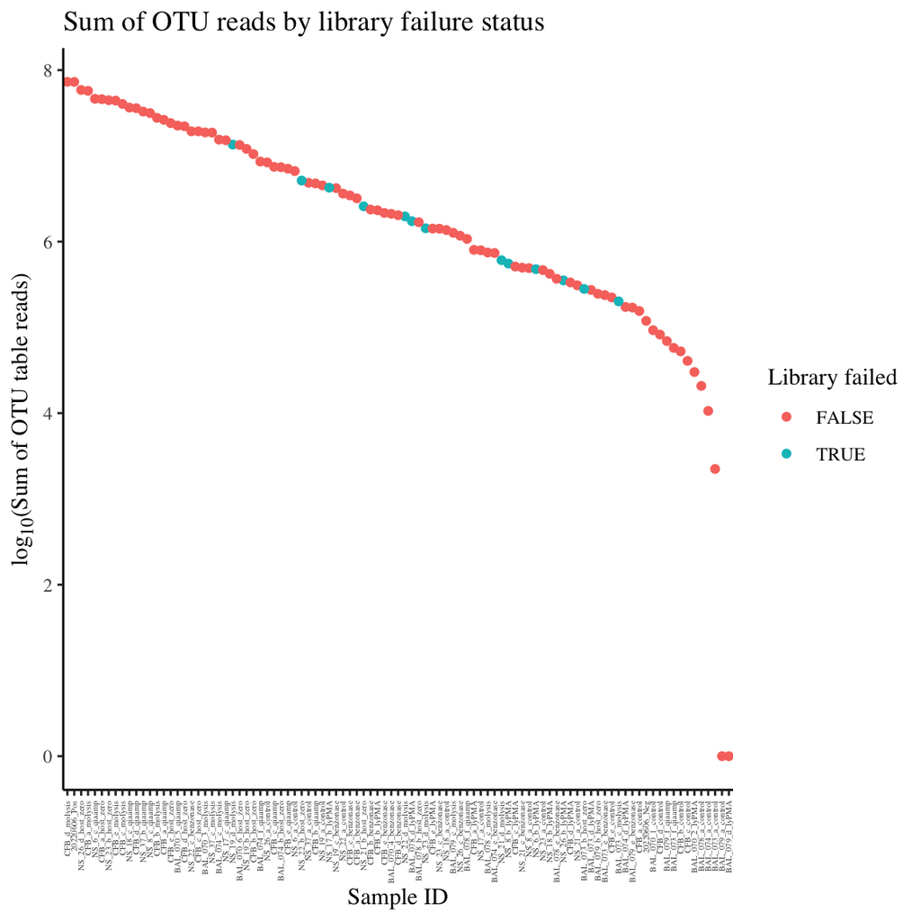

```r
#how were the samples failed in library prep?
sample_data %>% data.frame %>% mutate(total_read = phyloseq$phyloseq_count %>% otu_table %>% colSums()) %>% rownames_to_column(var = "baylor_other_id") %>%
        ggplot(aes(x = reorder(baylor_other_id, -total_read),
                               y = log10(total_read + 1),
                               col = lib_failed)) +
                geom_point() +
                theme_classic(base_family = "serif") +
                theme(axis.title.y = element_markdown(), axis.text.x = element_text(angle = 90, vjust = 0.5, hjust=1, size = 4)) +
                ylab("log<sub>10</sub>(Sum of OTU table reads)") +
                xlab("Sample ID") +
        guides(col=guide_legend(title="Library failed")) +
        ggtitle("Sum of OTU reads by library failure status")
```

```r
sample_data %>% data.frame %>% filter(phyloseq$phyloseq_count %>% otu_table %>% colSums() == 0) # two BAL sampels showed 0 total reads
```

|  | Raw_reads | LowQual_removed | Reads_after_trim | Host_mapped | Final_reads | Metaphlan_mapped | sequencing_host_prop | extraction_id | study_id | sample_id | sample_type | subject_id | collection_date | original_sample | aliquot | frozen | cryo_preserve | volume | control | lypma | benzonase | host_zero | qiaamp | molysis | extraction_date | position | depletion_date | note | DNA_host_well | … |
| --- | --- | --- | --- | --- | --- | --- | --- | --- | --- | --- | --- | --- | --- | --- | --- | --- | --- | --- | --- | --- | --- | --- | --- | --- | --- | --- | --- | --- | --- | --- |
| BAL_079_d_lyPMA | 197522626 | 37634186 | 159888440 | 159453284 | 435156 | 97 | 0.8072659 | 28 | host_depletion | BAL_079 | BAL | BAL_079 | NA | BAL_079 | d | 1 | 0 | 1000 | 0 | 1 | 0 | 0 | 0 | 0 | 20220610 | D4 | 20220609 | 20230314_MGK_depletion_date_updated | 0.03487478 | … |
| BAL_079_a_control | 157272446 | 27724938 | 129547508 | 129242538 | 304970 | 59 | 0.8217748 | 7 | host_depletion | BAL_079 | BAL | BAL_079 | NA | BAL_079 | a | 1 | 0 | 1000 | 1 | 0 | 0 | 0 | 0 | 0 | 20220610 | G1 | NA | NA | 0.07550491 | … |

```r
sample_data(phyloseq$phyloseq_count) %>% data.frame() %>% subset(., .$lib_failed)
```

|  | Raw_reads | LowQual_removed | Reads_after_trim | Host_mapped | Final_reads | Metaphlan_mapped | sequencing_host_prop | extraction_id | study_id | sample_id | sample_type | subject_id | collection_date | original_sample | aliquot | frozen | cryo_preserve | volume | control | lypma | benzonase | host_zero | qiaamp | molysis | extraction_date | position | depletion_date | note | DNA_host_well | … |
| --- | --- | --- | --- | --- | --- | --- | --- | --- | --- | --- | --- | --- | --- | --- | --- | --- | --- | --- | --- | --- | --- | --- | --- | --- | --- | --- | --- | --- | --- | --- |
| NS_8_b_lyPMA | 12380552 | 2696802 | 9683750 | 8836042 | 847708 | 25290 | 0.71370340 | 33 | host_depletion | NS_8_b | Nasal swab | lab_member | 2021-10-25 | NS_8 | b | 1 | 0 | 200 | 0 | 1 | 0 | 0 | 0 | 0 | 20220324 | A5 | 20220317 | 20220314_MGK_depletion_date_updated | 6.200705e-04 | … |
| NS_6_b_lyPMA | 831354 | 135990 | 695364 | 171760 | 523604 | 16118 | 0.20660272 | 31 | host_depletion | NS_6_b | Nasal swab | lab_member | 2021-10-25 | NS_6 | b | 1 | 0 | 200 | 0 | 1 | 0 | 0 | 0 | 0 | 20220324 | G4 | 20220317 | 20220314_MGK_depletion_date_updated | 4.707924e-04 | … |
| NS_26_b_lyPMA | 8472446 | 1567944 | 6904502 | 6327530 | 576972 | 10979 | 0.74683627 | 61 | host_depletion | NS_26 | Nasal swab | NS_26 | 44529 | NS_26 | b | 1 | 0 | 0 | 0 | 1 | 0 | 0 | 0 | 0 | 20220610 | A1 | 20220609 | 20230314_MGK_depletion_date_updated | 5.067148e-04 | … |
| NS_23_d_molysis | 9895612 | 1791874 | 8103738 | 6356602 | 1747136 | 82759 | 0.64236573 | 75 | host_depletion | NS_23_d | Nasal swab | lab_member | 2021-11-29 | NS_23 | d | 1 | 0 | 200 | 0 | 0 | 0 | 0 | 0 | 1 | 20220324 | C10 | 20220318 | 20220314_MGK_depletion_date_updated | 1.588849e-03 | … |
| NS_22_d_molysis | 3895428 | 564946 | 3330482 | 167780 | 3162702 | 112758 | 0.04307101 | 74 | host_depletion | NS_22_d | Nasal swab | lab_member | 2021-11-22 | NS_22 | d | 1 | 0 | 200 | 0 | 0 | 0 | 0 | 0 | 1 | 20220324 | B10 | 20220318 | 20220314_MGK_depletion_date_updated | 3.146309e-03 | … |
| NS_22_b_host_zero | 11597060 | 1583642 | 10013418 | 270256 | 9743162 | 306067 | 0.02330384 | 39 | host_depletion | NS_22_b | Nasal swab | lab_member | 2021-11-22 | NS_22 | b | 1 | 0 | 200 | 0 | 0 | 0 | 1 | 0 | 0 | 20220324 | G5 | 20220317 | 20220314_MGK_depletion_date_updated | 6.659427e-03 | … |
| NS_21_d_molysis | 6266502 | 1241572 | 5024930 | 4229964 | 794966 | 29508 | 0.67501199 | 73 | host_depletion | NS_21_d | Nasal swab | lab_member | 2021-11-22 | NS_21 | d | 1 | 0 | 200 | 0 | 0 | 0 | 0 | 0 | 1 | 20220324 | A10 | 20220318 | 20220314_MGK_depletion_date_updated | 2.120044e-03 | … |
| NS_21_b_host_zero | 14186874 | 2464122 | 11722752 | 8061998 | 3660754 | 130654 | 0.56827163 | 38 | host_depletion | NS_21_b | Nasal swab | lab_member | 2021-11-22 | NS_21 | b | 1 | 0 | 200 | 0 | 0 | 0 | 1 | 0 | 0 | 20220324 | F5 | 20220317 | 20220314_MGK_depletion_date_updated | 2.187273e-03 | … |
| NS_19_d_molysis | 40816718 | 5939470 | 34877248 | 646954 | 34230294 | 847465 | 0.01585022 | 71 | host_depletion | NS_19_d | Nasal swab | lab_member | 2021-11-15 | NS_19 | d | 1 | 0 | 200 | 0 | 0 | 0 | 0 | 0 | 1 | 20220324 | G9 | 20220318 | 20220314_MGK_depletion_date_updated | 1.158591e-02 | … |
| NS_17_b_lyPMA | 9783736 | 1896672 | 7887064 | 2810518 | 5076546 | 319923 | 0.28726429 | 34 | host_depletion | NS_17_b | Nasal swab | lab_member | 2021-11-15 | NS_17 | b | 1 | 0 | 200 | 0 | 1 | 0 | 0 | 0 | 0 | 20220324 | B5 | 20220317 | 20220314_MGK_depletion_date_updated | 5.855248e-03 | … |

[output cut: 3 more lines]

*Results:*

*2.1.1 Modeling final read should be conducted with both linear and logistic regression. Host % need no transformation, and should be tested for both linear and binomial methods*

*2.1.2 13 samples failed in library prep*

*2.1.3. Two BAL sampels showed 0 total reads*

*2.1.4. Sequencing fail ≠ library prep fail*

Comments from Baylor:

Q: What was the lab’s criteria for deciding which samples failed library prep.? There were 13 samples that you pointed as failed but their sequencing result actually looks pretty good (ie similar to samples that didn’t fail library prep)

A: To determine whether a library attempt “passed or failed” the lab looks at the picogreen concentrations and a library fragment size distribution trace. The trace files are an output from either the Fragment Analyzer or TapeStation (a copy of the trace files for PQ00331 is attached). If a sample has a background level pico concentration and no discernable fragment concentration on the trace (i.e. a flat trace line) it is considered failed library. If the sample is below the level of detection of our standard library QC methods, it is considered failure. It’s still possible that there is some small amounts of library in those samples that were successfully sequenced, but often those samples do not generate a meaningful amount of sequence data.

# QC2 table

```r
#sequencing result by sample type and control (1/0)
options(dplyr.summarise.inform = FALSE)

sample_data %>% data.frame() %>%
        group_by(sample_type, treated) %>%
        summarise(N = n(),
                  `Raw reads<br>(median [IQR])<br>[reads x 10<sup>7</sup>]` = paste(format(round(median(Raw_reads/10000000),2),nsmall = 2, big.mark = ","), " [", format(round(quantile(Raw_reads/10000000, 0.25),2), nsmall = 2, big.mark = ","), ", ", format(round(quantile(Raw_reads/10000000, 0.75),2), nsmall = 2, big.mark = ","), "]", sep = ""),
                  `Host reads<br>(median [IQR])<br>[reads x 10<sup>7</sup>]` = paste(format(round(median(Host_mapped/10000000),2), nsmall = 2, big.mark = ","), " [", format(round(quantile(Host_mapped/10000000, 0.25),2), nsmall = 2, big.mark = ","), ", ", format(round(quantile(Host_mapped/10000000, 0.75),2), nsmall = 2, big.mark = ","), "]", sep = ""),
                  `Host reads proportion<br>(median [IQR])<br>[%]` = paste(format(round(median(sequencing_host_prop * 100),2), nsmall = 2, big.mark = ","), " [", format(round(quantile(sequencing_host_prop * 100, 0.25),2), nsmall = 2, big.mark = ","), ", ", format(round(quantile(sequencing_host_prop * 100, 0.75),2), nsmall = 2, big.mark = ","), "]", sep = ""),
                  `Final reads<br>(median [IQR])<br>[reads x 10<sup>7</sup>]` = paste(format(round(median(Final_reads/10000000),2), nsmall = 2, big.mark = ","), " [", format(round(quantile(Final_reads/10000000, 0.25),2), nsmall = 2, big.mark = ","), ", ", format(round(quantile(Final_reads/10000000, 0.75),2), nsmall = 2, big.mark = ","), "]", sep = ""),
        ) %>%
        rename(`Sample type` = sample_type, Treated = treated) %>%
        data.frame(check.names = F) %>% mutate_all(linebreak) %>% kbl(format = "html", escape = F) %>% kable_styling(full_width = 0, html_font = "serif")
```

| Sample type | Treated | N | Raw reads (median [IQR]) [reads x 10<sup>7</sup>] | Host reads (median [IQR]) [reads x 10<sup>7</sup>] | Host reads proportion (median [IQR]) [%] | Final reads (median [IQR]) [reads x 10<sup>7</sup>] |
| --- | --- | --- | --- | --- | --- | --- |
| BAL | 0 | 5 | 15.73 [6.35, 15.92] | 12.92 [5.21, 12.94] | 82.14 [82.12, 82.18] | 0.03 [0.03, 0.04] |
| BAL | 1 | 25 | 6.17 [4.57, 17.43] | 4.65 [2.78, 12.80] | 75.59 [69.38, 78.44] | 0.17 [0.10, 0.37] |
| Nasal swab | 0 | 10 | 13.09 [7.73, 16.93] | 10.05 [6.11, 13.04] | 77.34 [76.89, 79.45] | 0.48 [0.10, 0.87] |
| Nasal swab | 1 | 25 | 4.08 [0.99, 6.40] | 0.81 [0.26, 1.36] | 27.46 [13.51, 64.58] | 0.97 [0.17, 3.42] |
| Sputum | 0 | 5 | 8.59 [8.25, 9.27] | 6.87 [6.69, 7.50] | 80.61 [79.92, 80.89] | 0.06 [0.06, 0.09] |
| Sputum | 1 | 25 | 12.23 [10.34, 13.73] | 7.71 [3.76, 8.82] | 58.64 [39.71, 74.93] | 1.16 [0.47, 4.19] |
| Neg. ext. | 0 | 1 | 0.02 [0.02, 0.02] | 0.00 [0.00, 0.00] | 3.13 [3.13, 3.13] | 0.02 [0.02, 0.02] |
| Pos. ext. | 0 | 1 | 11.87 [11.87, 11.87] | 0.00 [0.00, 0.00] | 0.02 [0.02, 0.02] | 9.96 [9.96, 9.96] |

```r
sample_data %>% data.frame() %>%
        #dplyr::filter(sample_type %in% c("Sputum", "nasal_swab", "BAL")) %>%
        group_by (sample_type, treatment) %>%
        summarise(N = n(),
              `Raw reads<br>(median [IQR])<br>[reads x 10<sup>7</sup>]` = paste(format(round(median(Raw_reads/10000000),2), nsmall = 2, big.mark = ","), " [", format(round(quantile(Raw_reads/10000000, 0.25),2), nsmall = 2, big.mark = ","), ", ", format(round(quantile(Raw_reads/10000000, 0.75),2), nsmall = 2, big.mark = ","), "]", sep = ""),
              `Host reads<br>(median [IQR])<br>[reads x 10<sup>7</sup>]` = paste(format(round(median(Host_mapped/10000000),2), nsmall = 2, big.mark = ","), " [", format(round(quantile(Host_mapped/10000000, 0.25),2), nsmall = 2, big.mark = ","), ", ", format(round(quantile(Host_mapped/10000000, 0.75),2), nsmall = 2, big.mark = ","), "]", sep = ""),
              `Host reads proportion<br>(median [IQR])<br>[%]` = paste(format(round(median(sequencing_host_prop * 100),2), nsmall = 2, big.mark = ","), " [", format(round(quantile(sequencing_host_prop * 100, 0.25),2), nsmall = 2, big.mark = ","), ", ", format(round(quantile(sequencing_host_prop * 100, 0.75),2), nsmall = 2, big.mark = ","), "]", sep = ""),
              `Final reads<br>(median [IQR])<br>[reads x 10<sup>7</sup>]` = paste(format(round(median(Final_reads/10000000),2), nsmall = 2, big.mark = ","), " [", format(round(quantile(Final_reads/10000000, 0.25),2), nsmall = 2, big.mark = ","), ", ", format(round(quantile(Final_reads/10000000, 0.75),2), nsmall = 2, big.mark = ","), "]", sep = ""),
        ) %>% data.frame(check.names = F) %>%
        arrange(sample_type, treatment) %>%
        rename(`Sample type` = sample_type, Treatment = treatment) %>%
        mutate_all(linebreak) %>% kbl(format = "html", escape = F) %>% kable_styling(full_width = 0, html_font = "serif")
```

| Sample type | Treatment | N | Raw reads (median [IQR]) [reads x 10<sup>7</sup>] | Host reads (median [IQR]) [reads x 10<sup>7</sup>] | Host reads proportion (median [IQR]) [%] | Final reads (median [IQR]) [reads x 10<sup>7</sup>] |
| --- | --- | --- | --- | --- | --- | --- |
| BAL | Control | 5 | 15.73 [6.35, 15.92] | 12.92 [5.21, 12.94] | 82.14 [82.12, 82.18] | 0.03 [0.03, 0.04] |
| BAL | lyPMA | 5 | 5.72 [3.59, 13.41] | 4.65 [2.79, 10.90] | 80.73 [77.85, 81.18] | 0.06 [0.04, 0.10] |
| BAL | Benzonase | 5 | 18.59 [16.20, 23.63] | 14.77 [12.80, 18.16] | 79.02 [77.89, 79.45] | 0.17 [0.16, 0.22] |
| BAL | Host zero | 5 | 4.57 [2.32, 4.71] | 2.69 [1.61, 2.93] | 66.98 [57.17, 68.95] | 0.24 [0.13, 0.82] |
| BAL | Molysis | 5 | 4.76 [3.57, 4.86] | 2.78 [1.39, 3.61] | 74.39 [74.29, 75.59] | 0.29 [0.13, 1.56] |
| BAL | QIAamp | 5 | 17.19 [15.35, 17.43] | 11.87 [10.79, 12.22] | 74.88 [71.08, 77.31] | 0.26 [0.10, 1.02] |
| Nasal swab | Control | 10 | 13.09 [7.73, 16.93] | 10.05 [6.11, 13.04] | 77.34 [76.89, 79.45] | 0.48 [0.10, 0.87] |
| Nasal swab | lyPMA | 5 | 0.98 [0.85, 1.24] | 0.63 [0.28, 0.88] | 71.37 [28.73, 74.68] | 0.07 [0.06, 0.08] |
| Nasal swab | Benzonase | 5 | 5.75 [4.95, 6.57] | 3.66 [1.29, 5.05] | 64.58 [63.71, 76.83] | 0.28 [0.26, 1.04] |
| Nasal swab | Host zero | 5 | 2.83 [1.42, 6.42] | 0.49 [0.03, 0.81] | 7.67 [2.33, 25.73] | 2.43 [0.97, 5.03] |
| Nasal swab | Molysis | 5 | 0.99 [0.63, 4.08] | 0.42 [0.06, 0.64] | 41.04 [4.31, 64.24] | 0.32 [0.17, 2.53] |
| Nasal swab | QIAamp | 5 | 6.40 [6.40, 6.80] | 0.86 [0.86, 1.17] | 17.24 [13.51, 19.57] | 4.63 [4.50, 4.67] |
| Sputum | Control | 5 | 8.59 [8.25, 9.27] | 6.87 [6.69, 7.50] | 80.61 [79.92, 80.89] | 0.06 [0.06, 0.09] |
| Sputum | lyPMA | 5 | 10.98 [5.22, 12.78] | 8.82 [3.76, 10.44] | 76.33 [72.02, 80.29] | 0.25 [0.15, 0.44] |
| Sputum | Benzonase | 5 | 10.76 [10.34, 10.82] | 7.81 [7.75, 8.24] | 74.93 [72.13, 75.33] | 0.47 [0.45, 0.59] |
| Sputum | Host zero | 5 | 13.14 [7.64, 13.95] | 4.39 [3.80, 7.71] | 49.71 [31.45, 55.49] | 2.91 [2.36, 3.67] |
| Sputum | Molysis | 5 | 12.59 [10.84, 13.73] | 2.98 [1.83, 4.28] | 27.49 [14.62, 28.19] | 6.11 [5.56, 8.37] |
| Sputum | QIAamp | 5 | 12.35 [12.23, 12.85] | 9.08 [8.41, 9.27] | 71.76 [56.69, 73.50] | 1.16 [1.13, 3.89] |
| Neg. ext. | Control | 1 | 0.02 [0.02, 0.02] | 0.00 [0.00, 0.00] | 3.13 [3.13, 3.13] | 0.02 [0.02, 0.02] |
| Pos. ext. | Control | 1 | 11.87 [11.87, 11.87] | 0.00 [0.00, 0.00] | 0.02 [0.02, 0.02] | 9.96 [9.96, 9.96] |

# QC2 figure

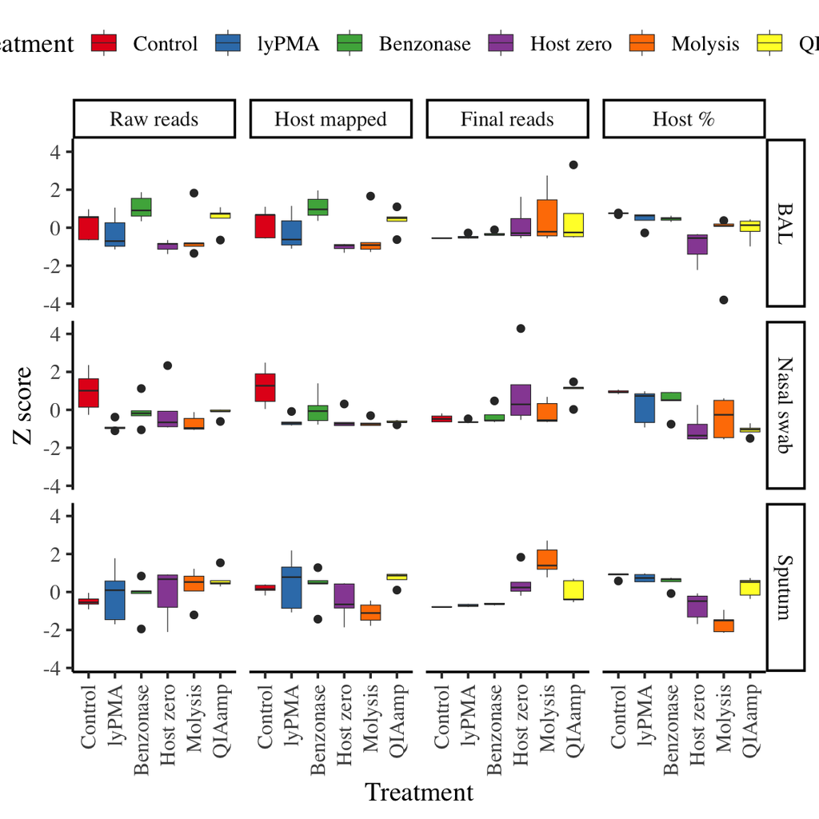

```r
# Summary figures - facet and z-score -------------------------------------

sample_data %>%
        subset(., !is.na(.$subject_id)) %>%
        data.frame() %>%
        gather(feature, value, Raw_reads:sequencing_host_prop) %>%
        group_by(feature, sample_type) %>%
        subset(., .$feature %in% c("Raw_reads", "Host_mapped", "Final_reads", "sequencing_host_prop")) %>%
        mutate(z_score = scale(value),
               feature = factor(feature, levels = c("Raw_reads", "Host_mapped", "Final_reads", "sequencing_host_prop"), labels = c("Raw reads", "Host mapped", "Final reads", "Host %"))) %>%
        ggplot(aes(x = treatment, y = z_score, fill = treatment)) +
                geom_boxplot(lwd = 0.2) +
                guides(fill=guide_legend(title="Treatment", nrow = 1)) +
                facet_grid(sample_type~feature) +
                xlab("Treatment") +
                ylab("Z score") +
                theme_classic(base_family = "serif", base_size = 14) +
                guides( x =  guide_axis(angle = 90)) +
                theme(legend.position = "top") +
                scale_fill_manual(values = c("#e41a1c", "#377eb8", "#4daf4a", "#984ea3", "#ff7f00", "#ffff33"), name = "Treatment") #color using https://colorbrewer2.org/#type=qualitative&scheme=Set1&n=6
```

*Results:*

*2.2.2. The changes in final reads were varied by treatment and sample type*

comment: Should I normalize z-score to mean value of control?

# Q3. How was the extraction controls, both pos and neg?

```r
#Loading theoretical mock community

zymo_mock <- read_excel("/Users/minsikkim/Dropbox (Partners HealthCare)/@minsik/project_sicas2/data_raw/DAR_20210929_zymo_mock_data.xlsx") %>%
        data.frame(row.names = T) %>% rename(mock_theoretical = Mock) %>% mutate(mock_theoretical = mock_theoretical/100) %>%
        merge_phyloseq(otu_table(., taxa_are_rows = T), tax_table(phyloseq$phyloseq_count))

phyloseq_control_rel <- rbind(c("mock_theoretical", "mock")) %>% data.frame() %>%
        column_to_rownames(var = "X1") %>% rename(sample_type = X2) %>% #making sample_data of mock community
        merge_phyloseq(sample_data(.), zymo_mock) %>%
        merge_phyloseq(., subset_samples(phyloseq$phyloseq_rel, sample_type == "Pos. ext." | sample_type == "Neg. ext." )) #adding data of controls


#Species richness of each control groups
cat("Species richness\n")
```

```
## Species richness
```

```r
rowSums(t(otu_table(phyloseq_control_rel)) != 0)
```

```
## mock_theoretical     20220606_Pos     20220606_Neg
##               10               41                3
```

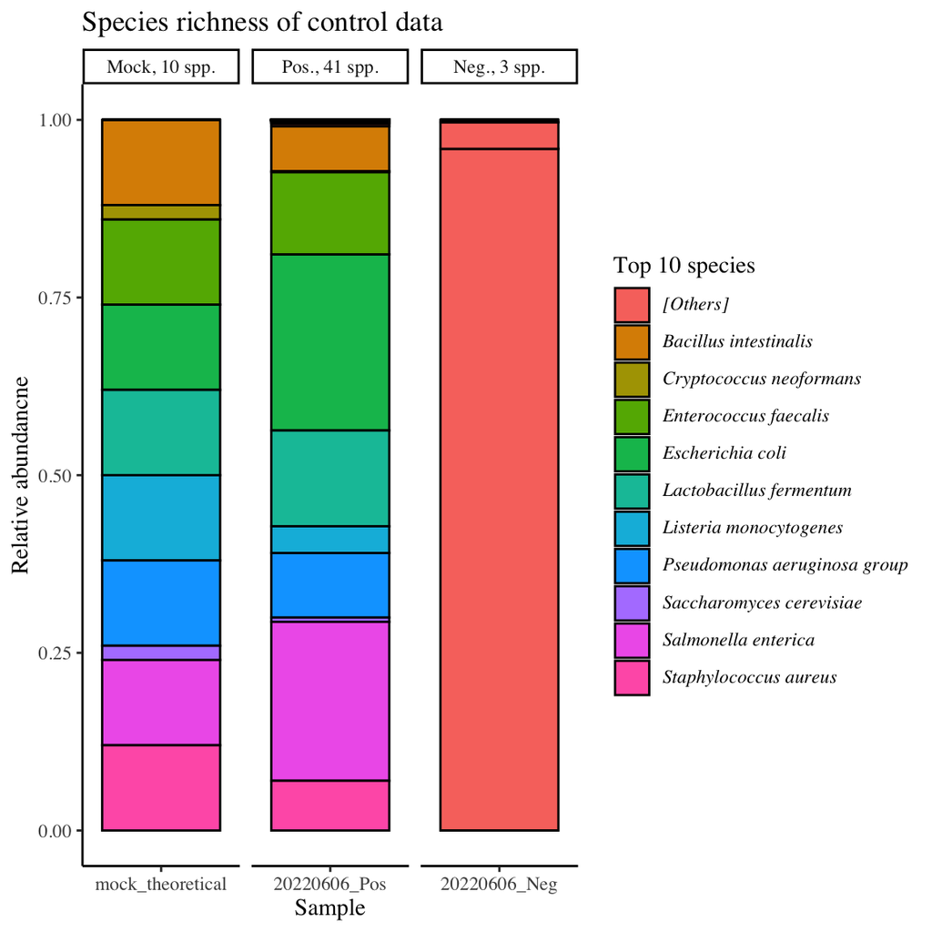

```r
sample_data(phyloseq_control_rel)$sample_type <- factor(sample_data(phyloseq_control_rel)$sample_type,
                                                        levels = c("mock", "2", "1"),
                                                        labels = c("Mock, 10 spp.", "Pos., 41 spp.", "Neg., 3 spp."))

#Manipulating phyloseq - only top 10

tax_table(phyloseq_control_rel) %>%
  cbind(species10 = "[Others]") %>%
  {top10species <- head(taxa_sums(phyloseq_control_rel), 10) %>% names()
   .[top10species, "species10"] <- as.character(.[top10species, "Species"])
   .[, 8] <- .[, 8] %>% gsub("s__", "", .) %>% gsub("_", " ", .) %>% paste("<i>", ., "</i>", sep = "")
   phyloseq_temp <- phyloseq_control_rel
   tax_table(phyloseq_temp) <- tax_table(.)
   phyloseq_temp
  } %>%
        plot_bar(., fill="species10") +
        ylab("Relative abundancne") +
        theme_classic(base_size = 11, base_family = "serif") +
        ggtitle("Species richness of control data") +
        theme(legend.text = element_markdown()) +
        guides(fill=guide_legend(title="Top 10 species")) +
        facet_wrap (~ sample_type, scales= "free_x", nrow=1)
```

```r
#there could be opportunistic pathogens...
```

*Results*

*2.3.1. Negative control showed minimal number of possible contaminants*

*2.3.2. Positive control contained various contaminants*

*Results:*

*2.2.2. The changes in final reads were varied by treatment and sample type*

# Q4. Prevalence filtering - red flag

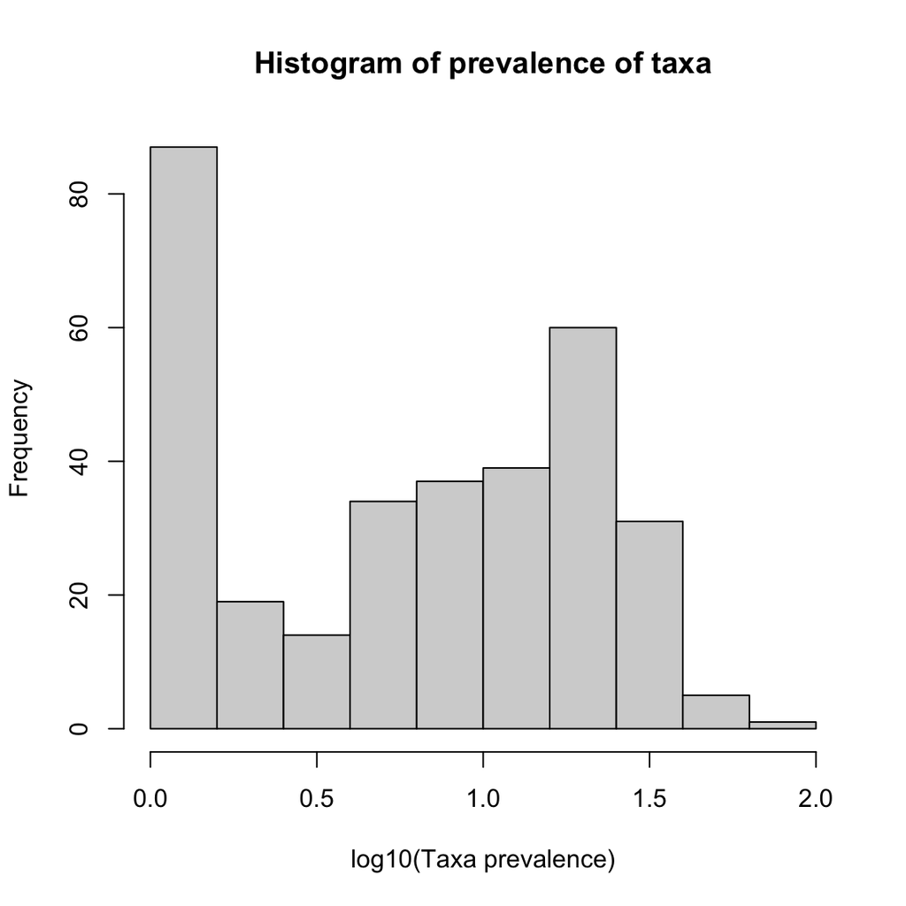

```r
#Calculation of sample prevalence, standard deviation, median abundance across all samples for all bugs and making into a table.
#
#•  In initial analysis we will not perform prevalence or abundance filtering (though we may consider this for secondary differential abundance analyses to manage p (features) > n (sample size) problem and issues with multiple hypothesis correction)
taxa_qc <- data.frame("species" =  otu_table(phyloseq$phyloseq_rel) %>% t() %>% colnames(),
        "prevalence" = ifelse(phyloseq$phyloseq_count %>% otu_table() > 0, 1, 0) %>% t() %>% colSums(), #Prevalence of taxa
        "mean_rel_abd" = phyloseq$phyloseq_rel %>% otu_table() %>% t() %>% colMeans(na.rm = T) #mean relativ abundacne
)


hist(log10(taxa_qc$prevalence), xlab = "log10(Taxa prevalence)", main = "Histogram of prevalence of taxa")
```

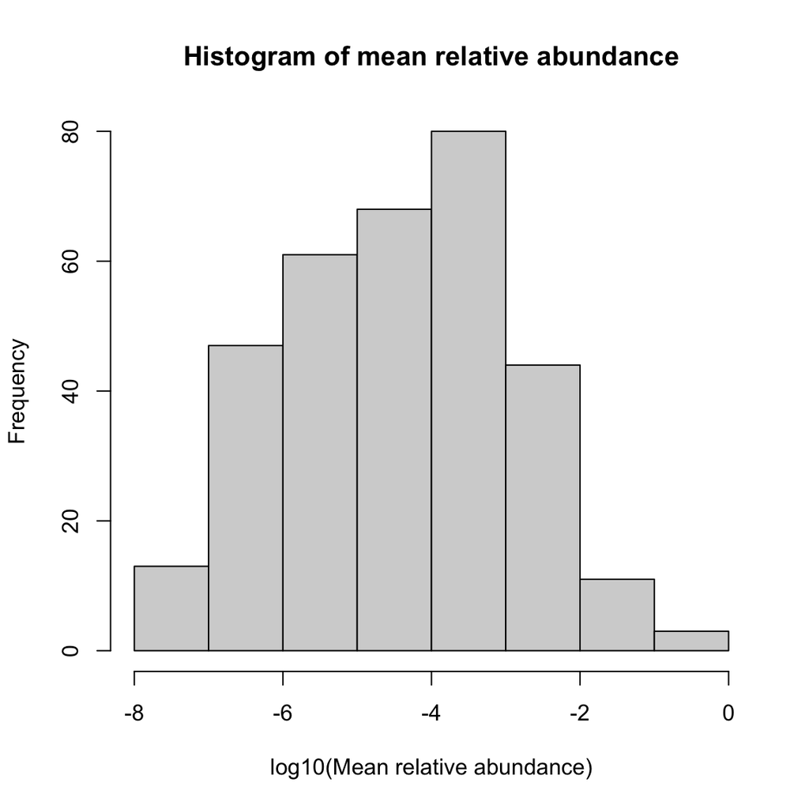

```r
hist(log10(taxa_qc$mean_rel_abd), xlab = "log10(Mean relative abundance)", main = "Histogram of mean relative abundance")
```

• In initial analysis we will not perform prevalence or abundance filtering (though we may consider this for secondary differentialabundance analyses to manage p (features) > n (sample size) problem and issues with multiple hypothesis correction) • Calculation of sample prevalence, standard deviation, median abundance across all samples for all bugs and making into a table.

Although we don’t consider the prevalence of abundance at this time, we can consider their red-flags after running the DA analysis

- 2. red flag

```r
red_flag_taxa <- data.frame(species = taxa_qc$species,
                          red_flag_prev_abd = ifelse(taxa_qc$prevalence < otu_table(phyloseq$phyloseq_rel) %>% t %>% rownames() %>% length * 0.05 & taxa_qc$mean_rel_abd < quantile(taxa_qc$mean_rel_abd, 0.75), 1, 0)
)
```

#*Analysis*#

# A0. calculation of alpha-diversity indices

```r
alpha_diversity <- function(data) {
        otu_table <- otu_table(data) %>% .[colSums(.) !=0]
        S.obs <- rowSums(t(otu_table) != 0)
        sample_data <- sample_data(data)
        data_evenness <- vegan::diversity(t(otu_table)) / log(vegan::specnumber(t(otu_table))) # calculate evenness index using vegan package
        data_shannon <- vegan::diversity(t(otu_table), index = "shannon") # calculate Shannon index using vegan package
        data_hill <- exp(data_shannon)                           # calculate Hills index

        data_dominance <- microbiome::dominance(otu_table, index = "all", rank = 1, aggregate = TRUE) # dominance (Berger-Parker index), etc.
        data_invsimpson <- vegan::diversity(t(otu_table), index = "invsimpson")                          # calculate Shannon index using vegan package
        alpha_diversity <- cbind(S.obs, data_shannon, data_hill, data_invsimpson, data_evenness,data_dominance) # combine all indices in one data table
        sample_data <- merge(data.frame(sample_data), alpha_diversity, by = 0, all = T) %>% column_to_rownames(var = "Row.names")
}

sample_data(phyloseq$phyloseq_rel) <- sample_data(alpha_diversity(phyloseq$phyloseq_count))
sample_data(phyloseq$phyloseq_count) <- sample_data(alpha_diversity(phyloseq$phyloseq_count))
sample_data(phyloseq$phyloseq_path_rpkm) <- sample_data(alpha_diversity(phyloseq$phyloseq_path_rpkm))
```

# A1. qPCR, by smaple type and treatment

```
    A. Total DNA
    B. Host DNA
    C. Bacterial DNA
    D. Host %
```

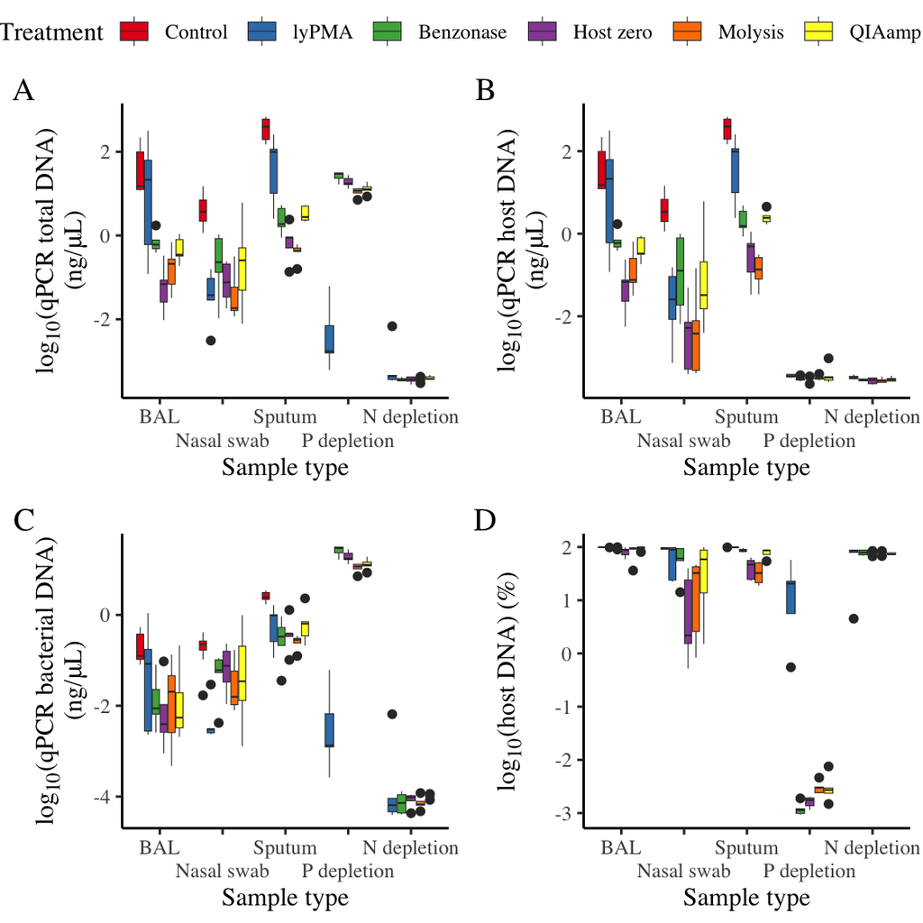

```r
#2A: Change in total DNA (qPCR)


f2a <- ggplot(data_qPCR, aes(x = sample_type, y = log10(DNA_host_nondil + DNA_bac_nondil))) +
        geom_boxplot(aes(fill = treatment), lwd = 0.2) +
        scale_fill_manual(values = c("#e41a1c", "#377eb8", "#4daf4a", "#984ea3", "#ff7f00", "#ffff33")) + #color using https://colorbrewer2.org/#type=qualitative&scheme=Set1&n=6
        ylab("log<sub>10</sub>(qPCR total DNA)<br>(ng/μL)") +
        xlab("Sample type") +
        theme_classic (base_size = 12, base_family = "serif") +
        labs(tag = "A") +
        scale_x_discrete(guide = guide_axis(n.dodge = 2)) +
        theme(plot.tag = element_text(size = 15), axis.title.y = element_markdown()) +              # Plot title size
        guides(fill = guide_legend(nrow = 1, title = "Treatment"))


#2B: Change in human DNA (qPCR)
f2b <- ggplot(data_qPCR, aes(x = sample_type, y = log10(DNA_host_nondil))) +
        geom_boxplot(aes(fill = treatment), lwd = 0.2) +
        scale_fill_manual(values = c("#e41a1c", "#377eb8", "#4daf4a", "#984ea3", "#ff7f00", "#ffff33")) +
        ylab("log<sub>10</sub>(qPCR host DNA)<br>(ng/μL)") +
        xlab("Sample type") +
        theme_classic (base_size = 12, base_family = "serif")+
        labs(tag = "B") +
        scale_x_discrete(guide = guide_axis(n.dodge = 2)) +
        theme(plot.tag = element_text(size = 15), axis.title.y = element_markdown()) +              # Plot title size
        guides(fill = guide_legend(nrow = 1, title = "Treatment"))
#2C: Change in 16S DNA (qPCR)
f2c <- ggplot(data_qPCR, aes(x = sample_type, y = log10(DNA_bac_nondil))) +
        geom_boxplot(aes(fill = treatment), lwd = 0.2) +
        scale_fill_manual(values = c("#e41a1c", "#377eb8", "#4daf4a", "#984ea3", "#ff7f00", "#ffff33")) +
        ylab("log<sub>10</sub>(qPCR bacterial DNA)<br>(ng/μL)") +
        xlab("Sample type") +
        theme_classic (base_size = 12, base_family = "serif")+
        labs(tag = "C") +
        scale_x_discrete(guide = guide_axis(n.dodge = 2)) +
        theme(plot.tag = element_text(size = 15), axis.title.y = element_markdown()) +              # Plot title size
        guides(fill = guide_legend(nrow = 1, title = "Treatment"))

#2D. Change in % host (qPCR)
f2d <- ggplot(data_qPCR, aes(x = sample_type, y = log10(host_proportion * 100))) +
        geom_boxplot(aes(fill = treatment), lwd = 0.2) +
        scale_fill_manual(values = c("#e41a1c", "#377eb8", "#4daf4a", "#984ea3", "#ff7f00", "#ffff33")) +
        ylab("log<sub>10</sub>(host DNA) (%)") +
        xlab("Sample type") +
        theme_classic (base_size = 12, base_family = "serif") +
        labs(tag = "D") +
        scale_x_discrete(guide = guide_axis(n.dodge = 2)) +
        theme(plot.tag = element_text(size = 15), axis.title.y = element_markdown()) +              # Plot title size
        guides(fill = guide_legend(nrow = 1, title = "Treatment"))

#output for markdown
ggarrange(f2a, f2b, f2c, f2d, common.legend = T , align = "hv")
```

# A2. Sequencing results (treatment, raw reads, host reads, % host, final reads)

```
--> both stratified and nonstratified
 library prep % vs sample_type + treatment + sample_type * treatment + subject_id (binary)
log10(Final reads) vs sample_type + treatment + sample_type * treatment + subject_id (linear or binary, see regular and cumulative distribution)
Host DNA % vs sample_type + treatment + sample_type * treatment + subject_id (linear or binary, see regular and cumulative distribution)
--> both stratified and nonstratified
```

```r
cat("Binomial - library failed? \n\n")
```

```
## Binomial - library failed?
```

```r
glmer(lib_failed ~ sample_type + treatment + sample_type * treatment + (1|subject_id), data = sample_data %>% data.frame) %>%
        summary %>% .$coefficients %>% data.frame(check.names = F) %>%
        mutate(` ` = case_when(abs(`t value`) > 2 ~ "*", .default = " ")) %>%
        kbl(format = "html") %>% kable_styling(full_width = 0, html_font = "serif")
```

Estimate

Std. Error

t value

(Intercept)

0.0000000

0.1167011

0.0000000

sample_typeNasal swab

-0.0204626

0.1470919

-0.1391145

sample_typeSputum

0.0000000

0.1650403

0.0000000

treatmentlyPMA

0.2000000

0.1619675

1.2348160

treatmentBenzonase

0.0000000

0.1619675

0.0000000

treatmentHost zero

0.2000000

0.1619675

1.2348160

treatmentMolysis

0.2000000

0.1619675

1.2348160

treatmentQIAamp

0.0000000

0.1619675

0.0000000

sample_typeNasal swab:treatmentlyPMA

0.5978181

0.2143680

2.7887474

sample_typeSputum:treatmentlyPMA

-0.2000000

0.2290566

-0.8731468

sample_typeNasal swab:treatmentBenzonase

-0.0021819

0.2143680

-0.0101781

sample_typeSputum:treatmentBenzonase

0.0000000

0.2290566

0.0000000

sample_typeNasal swab:treatmentHost zero

0.1978181

0.2143680

0.9227971

sample_typeSputum:treatmentHost zero

-0.2000000

0.2290566

-0.8731468

sample_typeNasal swab:treatmentMolysis

0.6021819

0.2143680

2.8091035

sample_typeSputum:treatmentMolysis

-0.2000000

0.2290566

-0.8731468

sample_typeNasal swab:treatmentQIAamp

0.0021819

0.2143680

0.0101781

sample_typeSputum:treatmentQIAamp

0.0000000

0.2290566

0.0000000

```r
cat("Binomial - Final reads? \n\n")
```

```
## Binomial - Final reads?
```

```r
glmer(log10(Final_reads) ~ sample_type + treatment + sample_type * treatment + (1|subject_id), data = sample_data %>% data.frame) %>%
        summary %>% .$coefficients %>% data.frame(check.names = F) %>%
        mutate(` ` = case_when(abs(`t value`) > 2 ~ "*", .default = " ")) %>%
        kbl(format = "html") %>% kable_styling(full_width = 0, html_font = "serif")
```

Estimate

Std. Error

t value

(Intercept)

5.4933063

0.2095210

26.2184086

sample_typeNasal swab

1.1246781

0.2789651

4.0316080

sample_typeSputum

0.3332900

0.2963074

1.1248117

treatmentlyPMA

0.3521385

0.2733402

1.2882794

treatmentBenzonase

0.8109049

0.2733402

2.9666509

treatmentHost zero

0.9501904

0.2733402

3.4762193

treatmentMolysis

1.0358039

0.2733402

3.7894313

treatmentQIAamp

1.0480985

0.2733402

3.8344107

sample_typeNasal swab:treatmentlyPMA

-0.8774152

0.3621899

-2.4225278

sample_typeSputum:treatmentlyPMA

0.1879364

0.3865614

0.4861747

sample_typeNasal swab:treatmentBenzonase

-0.6887274

0.3621899

-1.9015642

sample_typeSputum:treatmentBenzonase

0.0349655

0.3865614

0.0904526

sample_typeNasal swab:treatmentHost zero

-0.1157121

0.3621899

-0.3194791

sample_typeSputum:treatmentHost zero

0.7231403

0.3865614

1.8706997

sample_typeNasal swab:treatmentMolysis

-0.8411412

0.3621899

-2.3223760

sample_typeSputum:treatmentMolysis

0.9543008

0.3865614

2.4686913

sample_typeNasal swab:treatmentQIAamp

0.0236242

0.3621899

0.0652260

sample_typeSputum:treatmentQIAamp

0.3676901

0.3865614

0.9511817

```r
cat("Linear - Final reads? \n\n")
```

```
## Linear - Final reads?
```

```r
lmer(log10(Final_reads) ~ sample_type + treatment + sample_type * treatment + (1|subject_id), data = sample_data %>% data.frame) %>%
        summary %>% .$coefficients %>% data.frame(check.names = F) %>%
        mutate(` ` = case_when(abs(`Pr(>|t|)`) < 0.05 ~ "*", .default = " ")) %>%
        kbl(format = "html") %>% kable_styling(full_width = 0, html_font = "serif")
```

Estimate

Std. Error

df

t value

Pr(>|t|)

(Intercept)

5.4933063

0.2095210

62.79820

26.2184086

0.0000000

sample_typeNasal swab

1.1246781

0.2789651

37.26869

4.0316080

0.0002633

sample_typeSputum

0.3332900

0.2963074

62.79820

1.1248117

0.2649498

treatmentlyPMA

0.3521385

0.2733402

67.65016

1.2882794

0.2020376

treatmentBenzonase

0.8109049

0.2733402

67.65016

2.9666509

0.0041580

treatmentHost zero

0.9501904

0.2733402

67.65016

3.4762193

0.0008929

treatmentMolysis

1.0358039

0.2733402

67.65016

3.7894313

0.0003238

treatmentQIAamp

1.0480985

0.2733402

67.65016

3.8344107

0.0002788

sample_typeNasal swab:treatmentlyPMA

-0.8774152

0.3621899

68.18953

-2.4225278

0.0180749

sample_typeSputum:treatmentlyPMA

0.1879364

0.3865614

67.65016

0.4861747

0.6284145

sample_typeNasal swab:treatmentBenzonase

-0.6887274

0.3621899

68.18953

-1.9015642

0.0614539

sample_typeSputum:treatmentBenzonase

0.0349655

0.3865614

67.65016

0.0904526

0.9281949

sample_typeNasal swab:treatmentHost zero

-0.1157121

0.3621899

68.18953

-0.3194791

0.7503399

sample_typeSputum:treatmentHost zero

0.7231403

0.3865614

67.65016

1.8706997

0.0657128

sample_typeNasal swab:treatmentMolysis

-0.8411412

0.3621899

68.18953

-2.3223760

0.0232052

sample_typeSputum:treatmentMolysis

0.9543008

0.3865614

67.65016

2.4686913

0.0160928

sample_typeNasal swab:treatmentQIAamp

0.0236242

0.3621899

68.18953

0.0652260

0.9481849

sample_typeSputum:treatmentQIAamp

0.3676901

0.3865614

67.65016

0.9511817

0.3448982

```r
cat("Binomial - Host DNA proportion? \n\n")
```

```
## Binomial - Host DNA proportion?
```

```r
glmer(sequencing_host_prop ~ sample_type + treatment + sample_type * treatment + (1|subject_id), data = sample_data %>% data.frame) %>%
        summary %>% .$coefficients %>% data.frame(check.names = F) %>%
        mutate(` ` = case_when(abs(`t value`) > 2 ~ "*", .default = " ")) %>%
        kbl(format = "html") %>% kable_styling(full_width = 0, html_font = "serif")
```

Estimate

Std. Error

t value

(Intercept)

0.8200713

0.0646272

12.6892671

sample_typeNasal swab

-0.0378253

0.0799149

-0.4733196

sample_typeSputum

-0.0293956

0.0913966

-0.3216265

treatmentlyPMA

-0.0377605

0.0908962

-0.4154243

treatmentBenzonase

-0.0324363

0.0908962

-0.3568498

treatmentHost zero

-0.2000025

0.0908962

-2.2003393

treatmentMolysis

-0.1577230

0.0908962

-1.7351990

treatmentQIAamp

-0.0928027

0.0908962

-1.0209737

sample_typeNasal swab:treatmentlyPMA

-0.1931415

0.1202628

-1.6059959

sample_typeSputum:treatmentlyPMA

0.0106590

0.1285467

0.0829196

sample_typeNasal swab:treatmentBenzonase

-0.1301969

0.1202628

-1.0826036

sample_typeSputum:treatmentBenzonase

-0.0432386

0.1285467

-0.3363648

sample_typeNasal swab:treatmentHost zero

-0.3924910

0.1202628

-3.2636117

sample_typeSputum:treatmentHost zero

-0.1532698

0.1285467

-1.1923278

sample_typeNasal swab:treatmentMolysis

-0.2637315

0.1202628

-2.1929608

sample_typeSputum:treatmentMolysis

-0.3863225

0.1285467

-3.0053090

sample_typeNasal swab:treatmentQIAamp

-0.5240678

0.1202628

-4.3576894

sample_typeSputum:treatmentQIAamp

-0.0370057

0.1285467

-0.2878775

```r
cat("Linear - Host DNA proportion? \n\n")
```

```
## Linear - Host DNA proportion?
```

```r
lmer(sequencing_host_prop ~ sample_type + treatment + sample_type * treatment + (1|subject_id), data = sample_data %>% data.frame) %>%
        summary %>% .$coefficients %>% data.frame(check.names = F) %>%
        mutate(` ` = case_when(abs(`Pr(>|t|)`) < 0.05 ~ "*", .default = " ")) %>%
        kbl(format = "html") %>% kable_styling(full_width = 0, html_font = "serif")
```

Estimate

Std. Error

df

t value

Pr(>|t|)

(Intercept)

0.8200713

0.0646272

75.67093

12.6892671

0.0000000

sample_typeNasal swab

-0.0378253

0.0799149

41.00023

-0.4733196

0.6384957

sample_typeSputum

-0.0293956

0.0913966

75.67093

-0.3216265

0.7486224

treatmentlyPMA

-0.0377605

0.0908962

68.23467

-0.4154243

0.6791348

treatmentBenzonase

-0.0324363

0.0908962

68.23467

-0.3568498

0.7223055

treatmentHost zero

-0.2000025

0.0908962

68.23467

-2.2003393

0.0311715

treatmentMolysis

-0.1577230

0.0908962

68.23467

-1.7351990

0.0872202

treatmentQIAamp

-0.0928027

0.0908962

68.23467

-1.0209737

0.3108732

sample_typeNasal swab:treatmentlyPMA

-0.1931415

0.1202628

68.80454

-1.6059959

0.1128550

sample_typeSputum:treatmentlyPMA

0.0106590

0.1285467

68.23467

0.0829196

0.9341582

sample_typeNasal swab:treatmentBenzonase

-0.1301969

0.1202628

68.80454

-1.0826036

0.2827639

sample_typeSputum:treatmentBenzonase

-0.0432386

0.1285467

68.23467

-0.3363648

0.7376281

sample_typeNasal swab:treatmentHost zero

-0.3924910

0.1202628

68.80454

-3.2636117

0.0017148

sample_typeSputum:treatmentHost zero

-0.1532698

0.1285467

68.23467

-1.1923278

0.2372628

sample_typeNasal swab:treatmentMolysis

-0.2637315

0.1202628

68.80454

-2.1929608

0.0316937

sample_typeSputum:treatmentMolysis

-0.3863225

0.1285467

68.23467

-3.0053090

0.0037094

sample_typeNasal swab:treatmentQIAamp

-0.5240678

0.1202628

68.80454

-4.3576894

0.0000449

sample_typeSputum:treatmentQIAamp

-0.0370057

0.1285467

68.23467

-0.2878775

0.7743131

# A3. LM of taxa alpha diversity

```
--> both stratified and nonstratified
```

```r
sample_data <- sample_data(phyloseq$phyloseq_count) %>% data.frame(check.names = F) %>% subset(., !is.nan(.$simpson))

cat("Species richness of all samples\n\n")
```

```
## Species richness of all samples
```

```r
cat("S.obs ~ sample_type * treatment + log10 (Final_reads) + (1|original_sample)\n\n")
```

```
## S.obs ~ sample_type * treatment + log10 (Final_reads) + (1|original_sample)
```

```r
lmer(S.obs ~ sample_type * treatment + log10 (Final_reads) + (1|subject_id), data = sample_data) %>%
        summary() %>%
        .$coefficients %>%
        data.frame(check.names = F) %>%
        mutate(` ` = case_when(abs(`Pr(>|t|)`) < 0.05 ~ "*",
                               .default = " ")) %>%
        kbl(format = "html") %>%
        kable_styling(full_width = 0, html_font = "serif")
```

Estimate

Std. Error

df

t value

Pr(>|t|)

(Intercept)

-62.286176

18.946348

73.91996

-3.2875031

0.0015486

sample_typeNasal swab

-9.894010

13.143390

19.76996

-0.7527746

0.4604558

sample_typeSputum

5.066489

11.833705

23.07241

0.4281405

0.6725190

treatmentlyPMA

-3.032607

7.992068

64.29757

-0.3794521

0.7056025

treatmentBenzonase

-4.719045

8.051585

65.30664

-0.5861014

0.5598277

treatmentHost zero

-2.064590

8.208256

65.44300

-0.2515260

0.8021956

treatmentMolysis

10.862491

8.314322

65.52729

1.3064795

0.1959566

treatmentQIAamp

-2.491588

8.330143

65.53938

-0.2991050

0.7658063

log10(Final_reads)

12.532134

3.113656

67.56866

4.0248934

0.0001465

sample_typeNasal swab:treatmentlyPMA

4.202591

10.419319

64.56848

0.4033461

0.6880263

sample_typeSputum:treatmentlyPMA

34.664316

10.599221

64.21630

3.2704588

0.0017287

sample_typeNasal swab:treatmentBenzonase

1.775047

10.042806

64.92798

0.1767481

0.8602564

sample_typeSputum:treatmentBenzonase

62.518484

10.357810

64.45145

6.0358784

0.0000001

sample_typeNasal swab:treatmentHost zero

4.793943

9.787379

64.68743

0.4898086

0.6259264

sample_typeSputum:treatmentHost zero

92.094185

10.559614

64.43191

8.7213589

0.0000000

sample_typeNasal swab:treatmentMolysis

-7.289176

10.178107

65.15977

-0.7161623

0.4764500

sample_typeSputum:treatmentMolysis

87.197251

10.723044

64.48528

8.1317631

0.0000000

sample_typeNasal swab:treatmentQIAamp

-3.726532

9.774308

64.66718

-0.3812579

0.7042616

sample_typeSputum:treatmentQIAamp

70.548734

10.400892

64.40670

6.7829501

0.0000000

```r
#Species richness  - stratified
cat("Species richness at NS\n\n")
```

```
## Species richness at NS
```

```r
cat("S.obs ~ sample_type + log10 (Final_reads) + (1|original_sample)\n\n")
```

```
## S.obs ~ sample_type + log10 (Final_reads) + (1|original_sample)
```

```r
lmer(S.obs ~ treatment + log10 (Final_reads) + (1|subject_id), data = subset(sample_data, sample_data$sample_type == "Nasal swab")) %>%
        summary() %>%
        .$coefficients %>%
        data.frame(check.names = F) %>%
        mutate(` ` = case_when(abs(`Pr(>|t|)`) < 0.05 ~ "*",
                               .default = " ")) %>%
        kbl(format = "html") %>%
        kable_styling(full_width = 0, html_font = "serif")
```

Estimate

Std. Error

df

t value

Pr(>|t|)

(Intercept)

-26.0233860

9.340261

28

-2.7861520

0.0094654

treatmentlyPMA

-2.1153025

2.324810

28

-0.9098818

0.3706512

treatmentBenzonase

-1.7637014

2.206148

28

-0.7994486

0.4307605

treatmentHost zero

8.8224892

2.495655

28

3.5351399

0.0014386

treatmentMolysis

4.5783098

2.217883

28

2.0642703

0.0483678

treatmentQIAamp

0.8360832

2.678401

28

0.3121575

0.7572336

log10(Final_reads)

5.6349921

1.419898

28

3.9685903

0.0004571

```r
cat("Species richness at BAL\n\n")
```

```
## Species richness at BAL
```

```r
cat("S.obs ~ sample_type + log10 (Final_reads) + (1|original_sample)\n\n")
```

```
## S.obs ~ sample_type + log10 (Final_reads) + (1|original_sample)
```

```r
lmer(S.obs ~ treatment + log10 (Final_reads) + (1|original_sample), data = subset(sample_data, sample_data$sample_type == "BAL")) %>%
        summary() %>%
        .$coefficients %>%
        data.frame(check.names = F) %>%
        mutate(` ` = case_when(abs(`Pr(>|t|)`) < 0.05 ~ "*",
                               .default = " ")) %>%
        kbl(format = "html") %>%
        kable_styling(full_width = 0, html_font = "serif")
```

Estimate

Std. Error

df

t value

Pr(>|t|)

(Intercept)

-100.395549

25.504894

20.38095

-3.9363249

0.0007925

treatmentlyPMA

-5.839094

7.201885

17.39942

-0.8107731

0.4284473

treatmentBenzonase

-10.667780

7.752673

18.42945

-1.3760131

0.1853100

treatmentHost zero

-8.986746

8.091470

18.61512

-1.1106444

0.2808621

treatmentMolysis

3.342010

8.316699

18.72132

0.4018433

0.6923498

treatmentQIAamp

-10.097992

8.350027

18.73603

-1.2093364

0.2415732

log10(Final_reads)

19.520813

4.535759

19.97726

4.3037587

0.0003466

```r
cat("Species richness at sputum\n\n")
```

```
## Species richness at sputum
```

```r
cat("S.obs ~ sample_type + log10 (Final_reads) + (1|original_sample)\n\n")
```

```
## S.obs ~ sample_type + log10 (Final_reads) + (1|original_sample)
```

```r
lmer(S.obs ~ treatment + log10 (Final_reads) + (1|original_sample), data = subset(sample_data, sample_data$sample_type == "Sputum")) %>%
        summary() %>%
        .$coefficients %>%
        data.frame(check.names = F) %>%
        mutate(` ` = case_when(abs(`Pr(>|t|)`) < 0.05 ~ "*",
                               .default = " ")) %>%
        kbl(format = "html") %>%
        kable_styling(full_width = 0, html_font = "serif")
```

Estimate

Std. Error

df

t value

Pr(>|t|)

(Intercept)

-166.73637

94.19800

20.78908

-1.770063

0.0913826

treatmentlyPMA

21.48046

13.48708

19.68002

1.592670

0.1271695

treatmentBenzonase

41.90046

17.06102

19.99448

2.455918

0.0233254

treatmentHost zero

58.57768

28.77613

20.32431

2.035634

0.0550337

treatmentMolysis

60.65374

33.57099

20.37080

1.806731

0.0855997

treatmentQIAamp

41.44599

24.96239

20.26633

1.660337

0.1122410

log10(Final_reads)

31.32813

16.05007

20.49824

1.951899

0.0647464

```r
#Shannon
cat("Shannon index\n\n")
```

```
## Shannon index
```

```r
cat("Shannon ~ sample_type + log10 (Final_reads) + (1|original_sample)\n\n")
```

```
## Shannon ~ sample_type + log10 (Final_reads) + (1|original_sample)
```

```r
lmer(data_shannon ~ sample_type * treatment + log10 (Final_reads) + (1|original_sample), data = sample_data) %>%
        summary() %>%
        .$coefficients %>%
        data.frame(check.names = F) %>%
        mutate(` ` = case_when(abs(`Pr(>|t|)`) < 0.05 ~ "*",
                               .default = " ")) %>%
        kbl(format = "html") %>%
        kable_styling(full_width = 0, html_font = "serif")
```

Estimate

Std. Error

df

t value

Pr(>|t|)

(Intercept)

1.8948018

0.8689906

73.16148

2.1804629

0.0324397

sample_typeNasal swab

0.3612177

0.4227092

52.85894

0.8545299

0.3966679

sample_typeSputum

0.5229775

0.4502631

46.00549

1.1614932

0.2514323

treatmentlyPMA

0.1432302

0.3457153

59.27054

0.4143009

0.6801493

treatmentBenzonase

0.3245806

0.3510837

61.59790

0.9245107

0.3588282

treatmentHost zero

0.1622396

0.3591607

62.11606

0.4517187

0.6530450

treatmentMolysis

0.9220443

0.3646163

62.43914

2.5288070

0.0139853

treatmentQIAamp

0.3416438

0.3654292

62.48560

0.9349109

0.3534333

log10(Final_reads)

-0.2037567

0.1481509

70.28159

-1.3753323

0.1733965

sample_typeNasal swab:treatmentlyPMA

-0.3349724

0.4621995

62.11790

-0.7247356

0.4713354

sample_typeSputum:treatmentlyPMA

0.9305639

0.4573666

58.90852

2.0346129

0.0463989

sample_typeNasal swab:treatmentBenzonase

-0.1716183

0.4431174

62.20574

-0.3872975

0.6998579

sample_typeSputum:treatmentBenzonase

1.1940106

0.4466493

59.19803

2.6732618

0.0096921

sample_typeNasal swab:treatmentHost zero

0.1836222

0.4309190

61.71186

0.4261176

0.6715048

sample_typeSputum:treatmentHost zero

1.4844081

0.4573881

59.56239

3.2454017

0.0019263

sample_typeNasal swab:treatmentMolysis

-0.6161157

0.4488821

62.42148

-1.3725557

0.1748022

sample_typeSputum:treatmentMolysis

0.9186726

0.4659713

59.93997

1.9715216

0.0532853

sample_typeNasal swab:treatmentQIAamp

-0.2466370

0.4305635

61.76297

-0.5728238

0.5688436

sample_typeSputum:treatmentQIAamp

1.0739999

0.4489918

59.21646

2.3920256

0.0199485

```r
#Simpson
cat("Inverse Simpson index\n\n")
```

```
## Inverse Simpson index
```

```r
cat("InvSimp ~ sample_type + log10 (Final_reads) + (1|original_sample)\n\n")
```

```
## InvSimp ~ sample_type + log10 (Final_reads) + (1|original_sample)
```

```r
lmer(data_invsimpson ~ sample_type * treatment + log10 (Final_reads) + (1|original_sample), data = sample_data) %>%
        summary() %>%
        .$coefficients %>%
        data.frame(check.names = F) %>%
        mutate(` ` = case_when(abs(`Pr(>|t|)`) < 0.05 ~ "*",
                               .default = " ")) %>%
        kbl(format = "html") %>%
        kable_styling(full_width = 0, html_font = "serif")
```

Estimate

Std. Error

df

t value

Pr(>|t|)

(Intercept)

5.0016985

4.1346231

73.75264

1.2097109

0.2302531

sample_typeNasal swab

-0.1347032

1.9113437

60.99582

-0.0704757

0.9440456

sample_typeSputum

0.3376540

2.0144643

55.69325

0.1676148

0.8674935

treatmentlyPMA

-0.0446283

1.6994301

60.26753

-0.0262607

0.9791362

treatmentBenzonase

-0.0159936

1.7179035

63.20493

-0.0093099

0.9926012

treatmentHost zero

-0.5969192

1.7555995

63.84335

-0.3400088

0.7349661

treatmentMolysis

2.8388719

1.7811019

64.24055

1.5938852

0.1158705

treatmentQIAamp

-0.2830161

1.7849044

64.29760

-0.1585609

0.8745118

log10(Final_reads)

-0.4205707

0.7102118

72.89587

-0.5921764

0.5555648

sample_typeNasal swab:treatmentlyPMA

-0.2501880

2.2597896

63.56198

-0.1107130

0.9121928

sample_typeSputum:treatmentlyPMA

3.6784976

2.2498385

59.81795

1.6350052

0.1073001

sample_typeNasal swab:treatmentBenzonase

0.5135753

2.1660273

63.71628

0.2371047

0.8133362

sample_typeSputum:treatmentBenzonase

8.4907847

2.1958416

60.21080

3.8667565

0.0002731

sample_typeNasal swab:treatmentHost zero

1.1519699

2.1086029

63.04119

0.5463190

0.5867750

sample_typeSputum:treatmentHost zero

7.4853477

2.2470527

60.66550

3.3311847

0.0014760

sample_typeNasal swab:treatmentMolysis

-2.0541758

2.1931699

64.02401

-0.9366241

0.3524716

sample_typeSputum:treatmentMolysis

4.7103881

2.2875456

61.13466

2.0591450

0.0437470

sample_typeNasal swab:treatmentQIAamp

0.4812870

2.1067028

63.07313

0.2284551

0.8200315

sample_typeSputum:treatmentQIAamp

5.7791599

2.2072771

60.23515

2.6182303

0.0111632

```r
#BPI
cat("Beger Parker index\n\n")
```

```
## Beger Parker index
```

```r
cat("BPI ~ sample_type + log10 (Final_reads) + (1|original_sample)\n\n")
```

```
## BPI ~ sample_type + log10 (Final_reads) + (1|original_sample)
```

```r
lmer(dbp ~ sample_type * treatment + log10 (Final_reads) + (1|original_sample), data = sample_data) %>%
        summary() %>%
        .$coefficients %>%
        data.frame(check.names = F) %>%
        mutate(` ` = case_when(abs(`Pr(>|t|)`) < 0.05 ~ "*",
                               .default = " ")) %>%
        kbl(format = "html") %>%
        kable_styling(full_width = 0, html_font = "serif")
```

Estimate

Std. Error

df

t value

Pr(>|t|)

(Intercept)

-0.0429030

0.3089340

73.34596

-0.1388743

0.8899301

sample_typeNasal swab

-0.2254845

0.1470717

55.46609

-1.5331600

0.1309210

sample_typeSputum

-0.1615566

0.1559725

48.85446

-1.0358016

0.3053947

treatmentlyPMA

-0.0992353

0.1244133

59.03815

-0.7976258

0.4282842

treatmentBenzonase

-0.2090856

0.1261407

61.68022

-1.6575576

0.1024850

treatmentHost zero

-0.1071198

0.1289953

62.26501

-0.8304161

0.4094764

treatmentMolysis

-0.3789439

0.1309245

62.62965

-2.8943694

0.0052227

treatmentQIAamp

-0.2002048

0.1312121

62.68208

-1.5258106

0.1320873

log10(Final_reads)

0.1455197

0.0528497

71.25889

2.7534627

0.0074764

sample_typeNasal swab:treatmentlyPMA

0.1074786

0.1660074

62.17039

0.6474324

0.5197358

sample_typeSputum:treatmentlyPMA

-0.1999551

0.1646342

58.63042

-1.2145416

0.2294101

sample_typeNasal swab:treatmentBenzonase

0.0783117

0.1591430

62.28479

0.4920838

0.6243901

sample_typeSputum:treatmentBenzonase

-0.2242934

0.1607441

58.96684

-1.3953444

0.1681450

sample_typeNasal swab:treatmentHost zero

-0.0843810

0.1548174

61.70491

-0.5450359

0.5876935

sample_typeSputum:treatmentHost zero

-0.4349677

0.1645678

59.37801

-2.6430911

0.0104899

sample_typeNasal swab:treatmentMolysis

0.1755526

0.1611877

62.54326

1.0891189

0.2802803

sample_typeSputum:treatmentMolysis

-0.2575968

0.1676125

59.80380

-1.5368593

0.1296021

sample_typeNasal swab:treatmentQIAamp

0.1096753

0.1546846

61.75206

0.7090255

0.4809770

sample_typeSputum:treatmentQIAamp

-0.2873906

0.1615851

58.98802

-1.7785712

0.0804633

# A4. Taxa beta diversity

Permanova (Taxa dist ~ log10(final reads) + sample_type + treatment + sample_type * treatment + subject_id) –> both stratified and nonstratified

```r
phyloseq_rel_nz <- subset_samples(phyloseq$phyloseq_rel, S.obs != 0 & sample_type %in% c("BAL", "Nasal swab", "Sputum"))

bray_perm_uni <- vegan::adonis2(distance(phyloseq_rel_nz, method="bray") ~ sample_type + log10(Final_reads) + treatment + subject_id,
                            data = phyloseq_rel_nz %>% sample_data %>% data.frame(check.names = F), permutations = 10000)

bray_perm <- vegan::adonis2(distance(phyloseq_rel_nz, method="bray") ~ sample_type + log10(Final_reads) + lypma + benzonase + host_zero + molysis + qiaamp + subject_id,
                            data = phyloseq_rel_nz %>% sample_data %>% data.frame(check.names = F), permutations = 10000)

bray_perm_strata <- vegan::adonis2(distance(phyloseq_rel_nz, method="bray") ~ sample_type + log10(Final_reads) + lypma + benzonase + host_zero + molysis + qiaamp,
                            data = phyloseq_rel_nz %>% sample_data %>% data.frame(check.names = F),
                            strata = phyloseq_rel_nz %>% sample_data %>% data.frame(check.names = F) %>% .$subject_id, permutations = 10000)

bray_perm_inter <- vegan::adonis2(distance(phyloseq_rel_nz, method="bray") ~ sample_type * treatment + log10(Final_reads) + subject_id,
                                  data = phyloseq_rel_nz %>% sample_data %>% data.frame(check.names = F), permutations = 10000)

bray_perm_ns <- vegan::adonis2(distance(subset_samples(phyloseq_rel_nz, sample_type == "Nasal swab"), method="bray") ~ lypma + benzonase + host_zero + molysis + qiaamp + log10(Final_reads) + subject_id,
                               data = subset_samples(phyloseq_rel_nz, sample_type == "Nasal swab") %>% sample_data %>% data.frame(check.names = F), permutations = 10000)

bray_perm_bal  <- vegan::adonis2(distance(subset_samples(phyloseq_rel_nz, sample_type == "BAL"), method="bray") ~  lypma + benzonase + host_zero + molysis + qiaamp + log10(Final_reads) + subject_id,
                                 data = subset_samples(phyloseq_rel_nz, sample_type == "BAL") %>% sample_data %>% data.frame(check.names = F), permutations = 10000)

bray_perm_spt <- vegan::adonis2(distance(subset_samples(phyloseq_rel_nz, sample_type == "Sputum"), method="bray") ~ lypma + benzonase + host_zero + molysis + qiaamp + log10(Final_reads) + subject_id,
                                data = subset_samples(phyloseq_rel_nz, sample_type == "Sputum") %>% sample_data %>% data.frame(check.names = F), permutations = 10000)

cat("\nUnivariate analysis\n")
```

```
##
## Univariate analysis
```

```r
bray_perm_uni %>% data.frame(check.names = F) %>% rownames_to_column("row.names") %>%
        mutate(row.names = case_when(row.names == "sample_type" ~ 'Sample type',
                                     row.names == "treatment" ~ 'Treatment',
                                     row.names == "subject_id" ~ 'Subject',
                                     row.names == "log10(Final_reads)" ~ 'log10(Final reads)',
                                     row.names == "Residual" ~ 'Residual',
                                     row.names == "Total" ~ 'Total')) %>% column_to_rownames('row.names') %>%
        round(3) %>% mutate(` ` = case_when(abs(`Pr(>F)`) < 0.05 ~ "*",
                               .default = " ")) %>%
        kbl(format = "html") %>%
        kable_styling(full_width = 0, html_font = "serif")
```

Df

SumOfSqs

R2

F

Pr(>F)

Sample type

2

13.429

0.371

56.251

0.000

log10(Final reads)

1

1.111

0.031

9.310

0.000

Treatment

5

1.213

0.033

2.033

0.001

Subject

10

11.639

0.321

9.751

0.000

Residual

74

8.833

0.244

NA

NA

Total

92

36.225

1.000

NA

NA

```r
cat("\nDetailed treatment\n")
```

```
##
## Detailed treatment
```

```r
bray_perm %>% data.frame(check.names = F) %>% rownames_to_column("row.names") %>%
        mutate(row.names = case_when(row.names == "sample_type" ~ 'Sample type',
                                     row.names == "lypma" ~ 'lyPMA',
                                     row.names == "benzonase" ~ 'Benzonase',
                                     row.names == "host_zero" ~ 'Host zero',
                                     row.names == "molysis" ~ 'Molysis',
                                     row.names == "qiaamp" ~ 'QIAamp',
                                     row.names == "subject_id" ~ 'Subject',
                                     row.names == "log10(Final_reads)" ~ 'log10(Final reads)',
                                     row.names == "Residual" ~ 'Residual',
                                     row.names == "Total" ~ 'Total')) %>% column_to_rownames('row.names') %>%
        round(3) %>% mutate(` ` = case_when(abs(`Pr(>F)`) < 0.05 ~ "*",
                               .default = " ")) %>%
        kbl(format = "html") %>%
        kable_styling(full_width = 0, html_font = "serif")
```

Df

SumOfSqs

R2

F

Pr(>F)

Sample type

2

13.429

0.371

56.251

0.000

log10(Final reads)

1

1.111

0.031

9.310

0.000

lyPMA

1

0.140

0.004

1.172

0.287

Benzonase

1

0.092

0.003

0.774

0.607

Host zero

1

0.157

0.004

1.312

0.218

Molysis

1

0.200

0.006

1.676

0.103

QIAamp

1

0.624

0.017

5.229

0.000

Subject

10

11.639

0.321

9.751

0.000

Residual

74

8.833

0.244

NA

NA

Total

92

36.225

1.000

NA

NA

```r
cat("\n Strata -detailed treatment\n")
```

```
##
##  Strata -detailed treatment
```

```r
bray_perm_strata %>% data.frame(check.names = F) %>% rownames_to_column('row.names') %>%
        mutate(row.names = case_when(row.names == "sample_type" ~ 'Sample type',
                                     row.names == "lypma" ~ 'lyPMA',
                                     row.names == "benzonase" ~ 'Benzonase',
                                     row.names == "host_zero" ~ 'Host zero',
                                     row.names == "molysis" ~ 'Molysis',
                                     row.names == "qiaamp" ~ 'QIAamp',
                                     row.names == "log10(Final_reads)" ~ 'log10(Final reads)',
                                     row.names == "Residual" ~ 'Residual',
                                     row.names == "Total" ~ 'Total')) %>% column_to_rownames('row.names') %>%
        round(3) %>% mutate(` ` = case_when(abs(`Pr(>F)`) < 0.05 ~ "*",
                               .default = " ")) %>%
        kbl(format = "html") %>%
        kable_styling(full_width = 0, html_font = "serif")
```

Df

SumOfSqs

R2

F

Pr(>F)

Sample type

2

13.429

0.371

27.550

0.000

log10(Final reads)

1

1.111

0.031

4.560

0.000

lyPMA

1

0.140

0.004

0.574

0.530

Benzonase

1

0.092

0.003

0.379

0.665

Host zero

1

0.157

0.004

0.643

0.406

Molysis

1

0.200

0.006

0.821

0.167

QIAamp

1

0.624

0.017

2.561

0.003

Residual

84

20.472

0.565

NA

NA

Total

92

36.225

1.000

NA

NA

```r
cat("\n Interaction term \n")
```

```
##
##  Interaction term
```

```r
bray_perm_inter %>% data.frame(check.names = F) %>% rownames_to_column("row.names") %>%
        mutate(row.names = case_when(row.names == "sample_type" ~ 'Sample type',
                                     row.names == "treatment" ~ 'Treatment',
                                     row.names == "subject_id" ~ 'Subject',
                                     row.names == "log10(Final_reads)" ~ 'log10(Final reads)',
                                     row.names == "sample_type:treatment" ~ 'Sample type X treatment',
                                     row.names == "Residual" ~ 'Residual',
                                     row.names == "Total" ~ 'Total')) %>% column_to_rownames('row.names') %>%
        round(3) %>% mutate(` ` = case_when(abs(`Pr(>F)`) < 0.05 ~ "*",
                               .default = " ")) %>%
        kbl(format = "html") %>%
        kable_styling(full_width = 0, html_font = "serif")
```

Df

SumOfSqs

R2

F

Pr(>F)

Sample type

2

13.429

0.371

65.605

0

Treatment

5

1.184

0.033

2.314

0

log10(Final reads)

1

1.140

0.031

11.142

0

Subject

10

11.639

0.321

11.372

0

Sample type X treatment

10

2.283

0.063

2.231

0

Residual

64

6.550

0.181

NA

NA

Total

92

36.225

1.000

NA

NA

```r
cat("\n Stratified - nasal swab \n")
```

```
##
##  Stratified - nasal swab
```

```r
bray_perm_ns %>% data.frame(check.names = F) %>% rownames_to_column('row.names') %>%
        mutate(row.names = case_when(row.names == "lypma" ~ 'lyPMA',
                                     row.names == "benzonase" ~ 'Benzonase',
                                     row.names == "host_zero" ~ 'Host zero',
                                     row.names == "molysis" ~ 'Molysis',
                                     row.names == "qiaamp" ~ 'QIAamp',
                                     row.names == "subject_id" ~ 'Subject id',
                                     row.names == "log10(Final_reads)" ~ 'log10(Final reads)',
                                     row.names == "Residual" ~ 'Residual',
                                     row.names == "Total" ~ 'Total')) %>% column_to_rownames('row.names') %>%
        round(3) %>% mutate(` ` = case_when(abs(`Pr(>F)`) < 0.05 ~ "*",
                               .default = " ")) %>%
        kbl(format = "html") %>%
        kable_styling(full_width = 0, html_font = "serif")
```

Df

SumOfSqs

R2

F

Pr(>F)

lyPMA

1

0.730

0.120

5.122

0.004

Benzonase

1

0.191

0.031

1.342

0.262

Host zero

1

0.171

0.028

1.201

0.306

Molysis

1

0.137

0.022

0.961

0.405

QIAamp

1

0.254

0.042

1.780

0.148

log10(Final reads)

1

0.428

0.070

3.007

0.036

Subject id

2

0.488

0.080

1.714

0.119

Residual

26

3.704

0.607

NA

NA

Total

34

6.103

1.000

NA

NA

```r
cat("\n Stratified - BAL \n")
```

```
##
##  Stratified - BAL
```

```r
bray_perm_bal %>% data.frame(check.names = F) %>% rownames_to_column('row.names') %>%
        mutate(row.names = case_when(row.names == "lypma" ~ 'lyPMA',
                                     row.names == "benzonase" ~ 'Benzonase',
                                     row.names == "host_zero" ~ 'Host zero',
                                     row.names == "molysis" ~ 'Molysis',
                                     row.names == "qiaamp" ~ 'QIAamp',
                                     row.names == "subject_id" ~ 'Subject id',
                                     row.names == "log10(Final_reads)" ~ 'log10(Final reads)',
                                     row.names == "Residual" ~ 'Residual',
                                     row.names == "Total" ~ 'Total')) %>% column_to_rownames('row.names') %>%
        round(3) %>% mutate(` ` = case_when(abs(`Pr(>F)`) < 0.05 ~ "*",
                               .default = " ")) %>%
        kbl(format = "html") %>%
        kable_styling(full_width = 0, html_font = "serif")
```

Df

SumOfSqs

R2

F

Pr(>F)

lyPMA

1

0.100

0.010

1.144

0.308

Benzonase

1

0.025

0.003

0.288

0.934

Host zero

1

0.086

0.009

0.990

0.418

Molysis

1

0.085

0.009

0.969

0.428

QIAamp

1

0.229

0.024

2.625

0.035

log10(Final reads)

1

1.482

0.152

16.966

0.000

Subject id

4

6.241

0.641

17.864

0.000

Residual

17

1.485

0.153

NA

NA

Total

27

9.734

1.000

NA

NA

```r
cat("\n Stratified - sputum \n")
```

```
##
##  Stratified - sputum
```

```r
bray_perm_spt %>% data.frame(check.names = F) %>% rownames_to_column('row.names') %>%
        mutate(row.names = case_when(row.names == "lypma" ~ 'lyPMA',
                                     row.names == "benzonase" ~ 'Benzonase',
                                     row.names == "host_zero" ~ 'Host zero',
                                     row.names == "molysis" ~ 'Molysis',
                                     row.names == "qiaamp" ~ 'QIAamp',
                                     row.names == "subject_id" ~ 'Subject id',
                                     row.names == "log10(Final_reads)" ~ 'log10(Final reads)',
                                     row.names == "Residual" ~ 'Residual',
                                     row.names == "Total" ~ 'Total')) %>% column_to_rownames('row.names') %>%
        round(3) %>% mutate(` ` = case_when(abs(`Pr(>F)`) < 0.05 ~ "*",
                               .default = " ")) %>%
        kbl(format = "html") %>%
        kable_styling(full_width = 0, html_font = "serif")
```

Df

SumOfSqs

R2

F

Pr(>F)

lyPMA

1

0.139

0.020

2.565

0.046

Benzonase

1

0.037

0.005

0.688

0.635

Host zero

1

0.171

0.025

3.150

0.018

Molysis

1

0.436

0.063

8.046

0.000

QIAamp

1

0.953

0.137

17.588

0.000

log10(Final reads)

1

0.172

0.025

3.174

0.017

Subject id

4

4.022

0.578

18.555

0.000

Residual

19

1.030

0.148

NA

NA

Total

29

6.960

1.000

NA

NA

# A5. DA analysis for taxa, by sample type and treatment

```
--> both stratified and nonstratified
--> look at level groups as well - phylum, etc.
```

```r
#DA analysis - MaAslin

sample_data(phyloseq_rel_nz)$log10.Final_reads <- log10(sample_data(phyloseq_rel_nz)$Final_reads)
sample_data(phyloseq_rel_nz)$sampletype_treatment <- paste(sample_data(phyloseq_rel_nz)$sample_type, sample_data(phyloseq_rel_nz)$treatment, sep = ":")

#Running MaAslin for all sample without decontam
#for taxa differentially abundant by host depletion method, look to see which ones overlap with potential contaminant taxa

# Maaslin - # # y ~ log(final reads) + sample_type + treatment  -----------

#all samples
maaslin_all = Maaslin2(input_data = otu_table(phyloseq_rel_nz) %>% t %>% data.frame(),
                input_metadata = phyloseq_rel_nz %>% sample_data %>% data.frame(check.names = F),
                output = "/Users/minsikkim/Dropbox (Partners HealthCare)/@minsik/project_host_dna_depletion/Data/maaslin_output",
                fixed_effects = c("sample_type", "log10.Final_reads","lypma", "benzonase", "host_zero", "molysis", "qiaamp"),
                transform = "LOG", #default
                normalization = "TSS", # default
                random_effects = c("subject_id"),
                reference = c("sample_type,BAL"),
                plot_heatmap = F,
                plot_scatter = F)
```

[output not shown]

[output cut: 116 more lines]

[output not shown]

```r
#Checking number of bugs for the main text of the manuscript
cat("Number of differentially abundant bugs by each metadata")
```

```
## Number of differentially abundant bugs by each metadata
```

```r
maaslin_all$results %>% subset(., .$qval < 0.1) %>% .$metadata %>% table()
```

```
## .
##         benzonase         host_zero log10.Final_reads             lypma
##                 8                 6                50                14
##           molysis            qiaamp       sample_type
##                 9                 2                66
```

```r
cat("Decreased bugs by each metadata")
```

```
## Decreased bugs by each metadata
```

```r
maaslin_all$results %>% subset(., .$qval < 0.1 & .$coef < 0) %>% .$metadata %>% table()
```

```
## .
##         benzonase         host_zero log10.Final_reads             lypma
##                 1                 1                 1                 2
##           molysis       sample_type
##                 1                 1
```

```r
cat("Incrased")
```

```
## Incrased
```

```r
maaslin_all$results %>% subset(., .$qval < 0.1 & .$coef > 0) %>% .$metadata %>% table()
```

```
## .
##         benzonase         host_zero log10.Final_reads             lypma
##                 7                 5                49                12
##           molysis            qiaamp       sample_type
##                 8                 2                65
```

```r
#NS
# # y ~ log(final reads) + sample_type + treatment

fit_data_ns = Maaslin2(input_data = otu_table(subset_samples(phyloseq_rel_nz, sample_type == "Nasal swab")) %>% t %>% data.frame(),
                       input_metadata = sample_data(subset_samples(phyloseq_rel_nz, sample_type == "Nasal swab")) %>% data.frame(),
                       output = "/Users/minsikkim/Dropbox (Partners HealthCare)/@minsik/project_host_dna_depletion/Data/maaslin_output",
                       fixed_effects = c("log10.Final_reads","lypma", "benzonase", "host_zero", "molysis", "qiaamp"),
                       transform = "LOG", #default
                       normalization = "TSS", # default
                       random_effects = c("subject_id"),
                       plot_heatmap = F,
                       plot_scatter = F)
```

[output not shown]

[output cut: 20 more lines]

```r
#Checking number of bugs for the main text of the manuscript
cat("Number of differentially abundant bugs by each metadata in NS")
```

```
## Number of differentially abundant bugs by each metadata in NS
```

```r
fit_data_ns$results %>% subset(., .$qval < 0.1) %>% .$metadata %>% table()
```

```
## .
##         benzonase         host_zero log10.Final_reads             lypma
##                 2                 6                 9                 4
##           molysis            qiaamp
##                 4                 1
```

```r
#bal
# # y ~ log(final reads) + sample_type + treatment

fit_data_bal = Maaslin2(input_data = otu_table(subset_samples(phyloseq_rel_nz, sample_type == "BAL")) %>% t %>% data.frame(),
                       input_metadata = sample_data(subset_samples(phyloseq_rel_nz, sample_type == "BAL")) %>% data.frame(),
                       output = "/Users/minsikkim/Dropbox (Partners HealthCare)/@minsik/project_host_dna_depletion/Data/maaslin_output",
                       fixed_effects = c("log10.Final_reads","lypma", "benzonase", "host_zero", "molysis", "qiaamp"),
                       transform = "LOG", #default
                       normalization = "TSS", # default
                       random_effects = c("subject_id"),
                       plot_heatmap = F,
                       plot_scatter = F)
```

[output not shown]

[output cut: 38 more lines]

[output not shown]

```r
cat("Number of differentially abundant bugs by each metadata in BAL")
```

```
## Number of differentially abundant bugs by each metadata in BAL
```

```r
fit_data_bal$results %>% subset(., .$qval < 0.1) %>% .$metadata %>% table()
```

```
## < table of extent 0 >
```

```r
#sputum
# # y ~ log(final reads) + sample_type + treatment

fit_data_spt = Maaslin2(input_data = otu_table(subset_samples(phyloseq_rel_nz, sample_type == "Sputum")) %>% t %>% data.frame(),
                       input_metadata = sample_data(subset_samples(phyloseq_rel_nz, sample_type == "Sputum")) %>% data.frame(),
                       output = "/Users/minsikkim/Dropbox (Partners HealthCare)/@minsik/project_host_dna_depletion/Data/maaslin_output",
                       fixed_effects = c("log10.Final_reads","lypma", "benzonase", "host_zero", "molysis", "qiaamp"),
                       transform = "LOG", #default
                       normalization = "TSS", # default
                       random_effects = c("subject_id"),
                       plot_heatmap = F,
                       plot_scatter = F)
```

[output not shown]

[output cut: 144 more lines]

[output not shown]

```r
cat("Number of differentially abundant bugs by each metadata in sputum")
```

```
## Number of differentially abundant bugs by each metadata in sputum
```

```r
fit_data_spt$results %>% subset(., .$qval < 0.1) %>% .$metadata %>% table()
```

```
## .
##         benzonase         host_zero log10.Final_reads             lypma
##                 8                 5                 1                 8
##           molysis            qiaamp
##                 8                 7
```

```r
cat("\nAdding control data to both all and stratified MaAslin will help identify the actual contaminant\n")
```

```
##
## Adding control data to both all and stratified MaAslin will help identify the actual contaminant
```

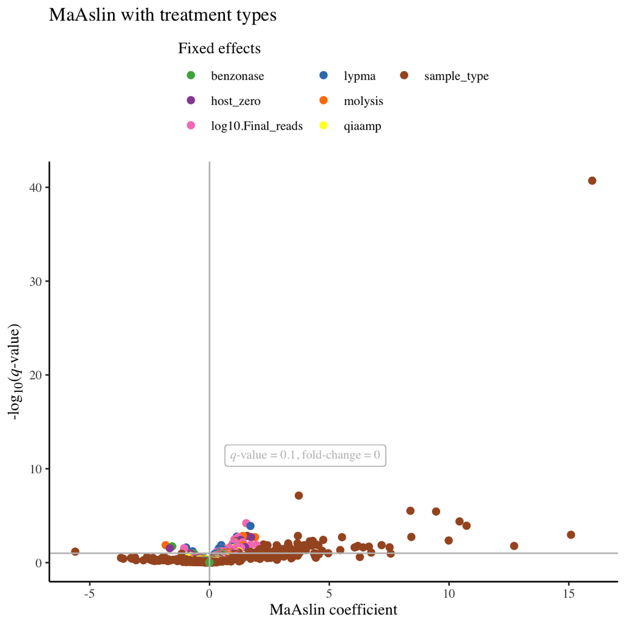

```r
#Making significance table for figure
        # Define a function to make species names italicized
species_italic <- function(data) {
  names <- gsub("_", " ", rownames(data))
  names <- gsub("[]]|[[]", "", names)
  names <- gsub(" sp", " sp.", names)
  names <- gsub(" sp.", "* sp.", names)
  names <- gsub(" group", "* group.", names)
  names <- ifelse(grepl("[*]", names), paste("*", names, sep = ""), paste("*", names, "*", sep = ""))
  rownames(data) <- names
  data
}

#volcano plot of MaAslin with all data

ggplot(maaslin_all$results, aes(y = -log10(qval), x = coef, col = metadata)) +
        theme_classic(base_family = "serif") +
        #labs(tag = "A") +
        ggtitle("MaAslin with treatment types")+
        geom_point(size = 2) +
        xlab("MaAslin coefficient") +
        ylab("-log<sub>10</sub>(*q*-value)") +
        geom_hline(yintercept = 1, col = "gray") +
        geom_vline(xintercept = 0, col = "gray") +
        geom_richtext(aes( 4, 8, label = "*q*-value = 0.1, fold-change = 0", vjust = -1, fontface = 1), col = "grey", size = 3, family = "serif") +
        theme(legend.position = "top", axis.title.y = ggtext::element_markdown()) +
        scale_color_manual(values = c("#4daf4a",  "#984ea3", "#f781bf", "#377eb8", "#ff7f00", "#ffff33", "#a65628")) +
        guides(col = guide_legend(title = "Fixed effects", title.position = "top", nrow = 3))
```

```r
# Make a significance table for each figure (top 20 taxa)


fit_data_spt$results
```

| feature | metadata | value | coef | stderr | pval | name | qval | N | N.not.zero |
| --- | --- | --- | --- | --- | --- | --- | --- | --- | --- |
| Streptococcus_infantis | lypma | lypma | 1.907577840 | 0.2793784 | 1.370983e-06 | lypma | 0.001414854 | 30 | 26 |
| Gemella_haemolysans | lypma | lypma | 1.051948913 | 0.1929170 | 2.452670e-05 | lypma | 0.008437186 | 30 | 25 |
| Streptococcus_infantis | benzonase | benzonase | 1.956232287 | 0.3536054 | 2.093568e-05 | benzonase | 0.008437186 | 30 | 26 |
| Gemella_haemolysans | benzonase | benzonase | 1.276721184 | 0.2431574 | 3.558437e-05 | benzonase | 0.009180769 | 30 | 25 |
| Bifidobacterium_longum | host_zero | host_zero | 6.275914612 | 1.3592257 | 1.717257e-04 | host_zero | 0.020194115 | 30 | 10 |
| Bifidobacterium_longum | molysis | molysis | 7.299180056 | 1.5862031 | 1.774626e-04 | molysis | 0.020194115 | 30 | 10 |
| Bifidobacterium_longum | qiaamp | qiaamp | 5.400455687 | 1.1786293 | 1.870364e-04 | qiaamp | 0.020194115 | 30 | 10 |
| Rothia_dentocariosa | lypma | lypma | 1.415061987 | 0.3169262 | 2.543832e-04 | lypma | 0.020194115 | 30 | 27 |
| Granulicatella_elegans | lypma | lypma | 1.646070116 | 0.3524142 | 1.570471e-04 | lypma | 0.020194115 | 30 | 24 |
| Streptococcus_sp_F0442 | lypma | lypma | 1.920071069 | 0.4302837 | 2.543429e-04 | lypma | 0.020194115 | 30 | 23 |

[output cut: 1022 more lines]

```r
make_sig_table <- function(data) {
  sig_data <- spread(data$results[order(data$results$qval), c("feature", "metadata", "qval")], metadata, qval)
  sig_data$min <- apply(sig_data, 1, FUN = min)
  sig_data <- sig_data[order(sig_data$min),] %>% .[1:20,]
  sig_data[["feature"]] <- ifelse(sig_data[["feature"]] == "X.Collinsella._massiliensis", "[Collinsella]_massiliensis", sig_data[["feature"]])
  sig_data_italic <- sig_data %>% rownames_to_column(var = "-") %>% column_to_rownames(var = "feature") %>% species_italic %>% select(-c("-", "min", "log10.Final_reads"))
  sig_data_sig <- ifelse(sig_data_italic < 0.1, "*", NA)
  return(list(data = sig_data, data_italic = sig_data_italic, data_sig = sig_data_sig))
}

fit_data_bal <- make_sig_table(fit_data_bal)
fit_data_ns <- make_sig_table(fit_data_ns)
fit_data_spt <- make_sig_table(fit_data_spt)

fit_data_ns$data
```

|  | feature | benzonase | host_zero | log10.Final_reads | lypma | molysis | qiaamp | min |
| --- | --- | --- | --- | --- | --- | --- | --- | --- |
| 10 | Cupriavidus_sp | 0.01161187 | 0.002711863 | 0.0009366596 | 0.0008918851 | 0.002711863 | 0.13275758 | 0.0008918851 |
| 29 | Streptococcus_oralis | 0.94696852 | 0.565070765 | 0.4734623066 | 0.8650511215 | 0.001319962 | 0.72157521 | 0.001319962 |
| 28 | Staphylococcus_epidermidis | 0.94386896 | 0.903510625 | 0.6284586389 | 0.0027118629 | 0.943868955 | 0.49815066 | 0.0027118629 |
| 30 | Sutterella_parvirubra | 0.72157521 | 0.044914770 | 0.8469017967 | 0.0027118629 | 0.189270119 | 0.51103635 | 0.0027118629 |
| 1 | Aeriscardovia_aeriphila | 0.71537252 | 0.903348386 | 0.0088091613 | 0.9427312853 | 0.955421771 | 0.94708772 | 0.0088091613 |
| 23 | Rothia_mucilaginosa | 0.30164878 | 0.033421738 | 0.0088091613 | 0.4734623066 | 0.030441111 | 0.17482974 | 0.0088091613 |
| 6 | Corynebacterium_atypicum | 0.78395888 | 0.856497615 | 0.0116118700 | 0.6509844661 | 0.843087069 | 0.44791623 | 0.0116118700 |
| 22 | Propionibacterium_namnetense | 0.71473399 | 0.623809520 | 0.0116118700 | 0.8475578977 | 0.943868955 | 0.86210879 | 0.0116118700 |
| 24 | Slackia_isoflavoniconvertens | 0.94273129 | 0.843087069 | 0.0132501061 | 0.9033483857 | 0.942731285 | 0.46424688 | 0.0132501061 |
| 12 | Cutibacterium_avidum | 0.67009891 | 0.170757910 | 0.0162333029 | 0.3016487762 | 0.670098908 | 0.34027731 | 0.0162333029 |

[output cut: 10 more lines]

```r
cat("\n\nStratified Masslin - significant of each but by treatment in BAL\n")
```

```
##
##
## Stratified Masslin - significant of each but by treatment in BAL
```

```r
fit_data_bal$data_sig
```

```
##                                      benzonase host_zero lypma molysis qiaamp
## *Actinomyces radingae*                      NA        NA    NA      NA     NA
## *Bulleidia extructa*                        NA        NA    NA      NA     NA
## *Candida dubliniensis*                      NA        NA    NA      NA     NA
## *Enterococcus avium*                        NA        NA    NA      NA     NA
## *Finegoldia magna*                          NA        NA    NA      NA     NA
## *Gemella morbillorum*                       NA        NA    NA      NA     NA
## *Peptostreptococcus* sp. MV1                NA        NA    NA      NA     NA
## *Peptostreptococcus stomatis*               NA        NA    NA      NA     NA
## *Rothia mucilaginosa*                       NA        NA    NA      NA     NA
## *Staphylococcus epidermidis*                NA        NA    NA      NA     NA
## *Staphylococcus schweitzeri*                NA        NA    NA      NA     NA
## *Varibaculum cambriense*                    NA        NA    NA      NA     NA
## *Actinomyces naeslundii*                    NA        NA    NA      NA     NA
## *Corynebacterium tuberculostearicum*        NA        NA    NA      NA     NA
## *Gemella asaccharolytica*                   NA        NA    NA      NA     NA
## *Gemella haemolysans*                       NA        NA    NA      NA     NA
## *Gemella sanguinis*                         NA        NA    NA      NA     NA
## *Negativicoccus succinicivorans*            NA        NA    NA      NA     NA
## *Sutterella parvirubra*                     NA        NA    NA      NA     NA
## *Prevotella oris*                           NA        NA    NA      NA     NA
```

```r
cat("\n\nStratified Masslin - significant of each but by treatment in nasal swab\n")
```

```
##
##
## Stratified Masslin - significant of each but by treatment in nasal swab
```

```r
fit_data_ns$data_sig
```

```
##                                benzonase host_zero lypma molysis qiaamp
## *Cupriavidus* sp.              "*"       "*"       "*"   "*"     NA
## *Streptococcus oralis*         NA        NA        NA    "*"     NA
## *Staphylococcus epidermidis*   NA        NA        "*"   NA      NA
## *Sutterella parvirubra*        NA        "*"       "*"   NA      NA
## *Aeriscardovia aeriphila*      NA        NA        NA    NA      NA
## *Rothia mucilaginosa*          NA        "*"       NA    "*"     NA
## *Corynebacterium atypicum*     NA        NA        NA    NA      NA
## *Propionibacterium namnetense* NA        NA        NA    NA      NA
## *Slackia isoflavoniconvertens* NA        NA        NA    NA      NA
## *Cutibacterium avidum*         NA        NA        NA    NA      NA
## *Staphylococcus aureus*        NA        NA        NA    NA      NA
## *Staphylococcus argenteus*     NA        "*"       NA    NA      NA
## *Collinsella massiliensis*     NA        NA        NA    NA      "*"
## *Limnochorda pilosa*           NA        NA        NA    "*"     NA
## *Corynebacterium accolens*     NA        NA        "*"   NA      NA
## *Malassezia restricta*         "*"       NA        NA    NA      NA
## *Collinsella intestinalis*     NA        "*"       NA    NA      NA
## *Finegoldia magna*             NA        "*"       NA    NA      NA
## *Gemella haemolysans*          NA        NA        NA    NA      NA
## *Thermoleophilum album*        NA        NA        NA    NA      NA
```

```r
cat("\n\nStratified Masslin - significant of each but by treatment in Sputum\n")
```

```
##
##
## Stratified Masslin - significant of each but by treatment in Sputum
```

```r
fit_data_spt$data_sig
```

```
##                                  benzonase host_zero lypma molysis qiaamp
## *Streptococcus infantis*         "*"       NA        "*"   NA      NA
## *Gemella haemolysans*            "*"       NA        "*"   NA      NA
## *Eubacterium sulci*              "*"       "*"       NA    "*"     "*"
## *Granulicatella elegans*         "*"       NA        "*"   NA      NA
## *Rothia dentocariosa*            "*"       NA        "*"   NA      NA
## *Streptococcus* sp. F0442        "*"       NA        "*"   NA      NA
## *Bifidobacterium longum*         "*"       "*"       NA    "*"     "*"
## *Pseudomonas aeruginosa* group.  NA        NA        NA    "*"     "*"
## *Neisseria flavescens*           "*"       NA        "*"   NA      NA
## *Rothia mucilaginosa*            NA        NA        "*"   NA      NA
## *Actinomyces naeslundii*         NA        "*"       NA    "*"     "*"
## *Denitrobacterium detoxificans*  NA        "*"       NA    "*"     "*"
## *Actinomyces* sp. oral taxon 897 NA        "*"       NA    "*"     "*"
## *Prevotella melaninogenica*      NA        NA        NA    "*"     "*"
## *Gemmata obscuriglobus*          NA        NA        NA    "*"     NA
## *Streptococcus gordonii*         NA        NA        "*"   NA      NA
## *Corynebacterium durum*          NA        NA        NA    NA      NA
## *Actinomyces* sp. HPA0247        NA        NA        NA    NA      NA
## *Streptococcus sanguinis*        NA        NA        NA    NA      NA
## *Actinomyces massiliensis*       NA        NA        NA    NA      NA
```

Results After adding control data, MaAslin needs to be reanalyzed. Adding controls (mock communities) for each treatment group will show more statistically valid results in y ~ log(final reads) + sample_type + treatment, (re = subject_id))